# Stability of self reports of maltreatment

Oonagh Coleman

2026-04-30

# Load packages

```r
library(readxl) # read in Excel data
library(psych) # for description of data
library(metafor) # for meta-analysis
library(MAd) # for aggregating effect sizes within studies
library(dplyr) # for data wrangling
library(effectsize) # for effect size conversions
library(ggplot2) # for plots
library(gridExtra) # for arranging plots
library(cowplot) # for arranging plots
library(forcats) # for handling categorical variables
library(mgsub) # for formatting strings
library(multcomp) # for pairwise comparisons
library(kableExtra) # for tables
library(plyr) # for renaming variables
library(ggpubr) # for arranging plots
library(DescTools) # for descriptive statistics, graphical tools etc
library(tidyr) # for tidying data
```

# Load data

```r
## Open dataset
data <- data.frame(readxl::read_excel(file.path(Data, "data_extraction_table_CODEOCEAN_260430.xlsx")))
str(data)

options(scipen = 999)
```

# Examine raw effect sizes

```r
# Examine types of effect sizes
table(data$ES_type)

## View studies with tetrachoric correlations
data %>% dplyr::filter (ES_type=="tetrachoric") %>%
  dplyr::select(author, ES_type, ES)

## View studies with ICC
data %>% dplyr::filter (ES_type=="ICC") %>%
  dplyr::select(author, ES_type, ES)

## View studies with correlation
data %>% dplyr::filter (ES_type=="correlation") %>%
  dplyr::select(author, ES_type, ES)

## View studies with other ES type
data %>% dplyr::filter(!ES_type %in% c("ICC", "correlation", "tetrachoric")) %>%
  dplyr::select(author, ES_type, ES)

## Exclude studies and rows with duplicates or unsupported ES types
data <- data %>%
  filter(ES_type %in% c("ICC", "correlation", "tetrachoric")) %>%
  filter(!(author == "Fergusson" & year == "2000")) %>%        #duplicate
  filter(!(author %in% c("Dubowitz"))) %>%                     #looking at new exposure
  filter(!(author == "Hosang" & ES_type == "tetrachoric"))     #duplicate
```

# Derive additional variables needed for meta-analysis

Before moving onto analysing the results, we will derive the following variables:

- study reference (combining the author name and year of publication)
- effect size ID (needed for multi-level meta-analysis models)
- type of child maltreatment (for moderation analyses)
- broad dimension of child maltreatment (for moderation analyses)
- binary baseline age variable (for moderation analysis)

```r
# Derive study reference, combining author name and year of publication
data$ref <- paste0(data$author, "_", data$year)

# Derive effect size ID (this is needed for multi-level meta-analysis)
data$es_id <- 1:nrow(data)

# Recode maltreatment type variable to reduce number of categories
table(data$exposure_type)
# Note: there are only 3 effect sizes for neglect
# recode neglect to physical neglect
data$exposure_type[data$exposure_type=="neglect"] <- "physical_neglect"

table(data$exposure_type)

# Derive broad dimension variable (abuse vs neglect)
data <- data %>%
  mutate(dimension = case_when(
    exposure_type %in% c("sexual_abuse", "physical_abuse", "emotional_abuse") ~ "abuse",
    exposure_type %in% c("emotional_neglect", "physical_neglect") ~ "neglect",
    exposure_type %in% c("maltreatment", "ACEs") ~ NA_character_
  ))

table(data$dimension)

# baseline age - binary variable
data$baseline_age_binary <- cut(data$baseline_age,
                             breaks = c(0, 18, 70),
                             labels = c("0-18", "18+"),  # Labels
                      right = FALSE)

table(data$baseline_age_binary)
```

# Z-transformation and variance calulation

Z-transformation of correlation effect sizes, and calculation of corresponding variance using the ‘escalc’ function

```r
# Convert effect size column to numeric
data$ES <- as.numeric(as.character(data$ES))

is.numeric(data$ES)


# Check for NA values introduced during conversion
sum(is.na(data$ES))


# Z-transformation
data <- escalc(measure="ZCOR", ri=ES, ni=followup_n,
              data=data)


# Identify rows with NA values in yi or vi
na_rows <- which(is.na(data$yi) | is.na(data$vi))
```

# Results

## Search results - descriptives

We will calculate descriptives on the number of studies, number of cohorts, baseline sample size, follow up sample size, and sample characteristics (percentage female, attrition, baseline age, follow up age, time interval).

```r
# Number of studies
k_studies <- data %>%
  group_by(ref) %>% # group by study reference
  dplyr::summarise(m = max(ref)) %>%  # select one row per study
  nrow() # count number of rows
k_studies

# Number of cohorts
n_cohort <- data %>%
  group_by(cohort) %>% # group by study cohort
  dplyr::summarise(m = max(cohort)) %>%  # select one row per study
  nrow() # count number of rows
n_cohort

# NOTE - the number of studies is 49 and the number of cohorts is 49, but there are actually two cohorts in one study, and one cohort across two studies

# Obtain total baseline N -
baseline_N <- data %>%
  group_by(cohort) %>%
  dplyr::summarise(m = max(baseline_n)) %>%  # make new column indexing largest sample size per distinct cohort
  dplyr::summarise(sum = sum(m),
                   min = min(m),
                   max = max(m)) # sum sample sizes across distinct cohorts
baseline_N

# Obtain total followup N -
followup_N <- data %>%
  group_by(cohort) %>%
  dplyr::summarise(m = max(followup_n)) %>%  # make new column indexing largest sample size per distinct cohort
  dplyr::summarise(sum = sum(m),
                   min = min(m),
                   max = max(m)) # sum sample sizes across distinct cohorts
followup_N

# Average proportion female
perc_female <- data %>%
  group_by(cohort) %>% # group by study cohort
  dplyr::summarise(mean_perc_female = mean(percent_female)) %>%  # calculate the average % female per cohort
  dplyr::summarise(overall=mean(mean_perc_female, na.rm=TRUE),
                   min_perc_female = min(mean_perc_female, na.rm = TRUE),
                   max_perc_female = max(mean_perc_female, na.rm = TRUE))

perc_female


# Age at baseline assessment
base_age <- data %>%
  group_by(cohort) %>%   # group by study cohort
  dplyr::summarise(mean_baseline_age = mean(baseline_age)) %>% # calculate the average age at assessment per cohort
  dplyr::summarise(overall=mean(mean_baseline_age, na.rm=TRUE),
                   min_base_age = min(mean_baseline_age, na.rm = TRUE),
                   max_base_age = max(mean_baseline_age, na.rm = TRUE),
                   med_base_age = median(mean_baseline_age, na.rm = TRUE)) # calculate the average age at assessment across cohorts
base_age

#Age at followup assessment
followup_age <- data %>%
  group_by(cohort) %>%   # group by study cohort
  dplyr::summarise(mean_followup_age = mean(followup_age)) %>% # calculate the average age at assessment per cohort
  dplyr::summarise(overall=mean(mean_followup_age, na.rm=TRUE),
                   min_followup_age = min(mean_followup_age, na.rm = TRUE),
                   max_followup_age = max(mean_followup_age, na.rm = TRUE)) # calculate the average age at assessment across cohorts
followup_age

#follow up time period
followup_interval <- data %>%
  group_by(cohort) %>%   # group by study cohort
  dplyr::summarise(mean_followup_interval = mean(followup_interval)) %>% # calculate the average age at assessment per cohort
  dplyr::summarise(overall=mean(mean_followup_interval, na.rm=TRUE),
                   min_followup_interval = min(mean_followup_interval, na.rm = TRUE),
                   max_followup_interval = max(mean_followup_interval, na.rm = TRUE)) # calculate the average age at assessment across cohorts
followup_interval
```

## Meta-analyses on the stability of maltreatment reports

In the next section we will: * conduct a multi-level random effects meta-analysis for the stability of retrospective self-reports over time * calculate $I^{2}$ value * create a forest plot showing study-average effect sizes

```r
# Basic model: random effects for effect size ID and reference
res <- rma.mv(yi, vi, random = list(~1 | es_id, ~1 | ref), data = data)

# Extended model: also includes cohort-level random effects
res1 <- rma.mv(yi, vi, random = list(~1 | es_id, ~1 | ref, ~1 | cohort), data = data)

# Compare models to test whether adding cohort improves fit
anova(res, res1)  # No significant difference → retain simpler model

# Back-transform overall effect estimate and confidence intervals from Z to r
transf.ztor(res$beta)    # Point estimate
transf.ztor(res$ci.lb)   # Lower bound
transf.ztor(res$ci.ub)   # Upper bound


# Sum of variance components across levels (for use in R² calculation)
tau2_res <- sum(res$sigma2)


# Calculate I2 statistic
#see: https://www.metafor-project.org/doku.php/tips:i2_multilevel_multivariate
# Create the weight matrix W
W <- diag(1/data$vi[!is.na(data$yi) & !is.na(data$vi)])

# Create the model matrix X
X <- model.matrix(res)

# Calculate the projection matrix P
P <- W - W %*% X %*% solve(t(X) %*% W %*% X) %*% t(X) %*% W

# Calculate the I² statistic
I2 <- 100 * sum(res$sigma2) / (sum(res$sigma2) +
                                           (res$k - res$p) / sum(diag(P)))

# Round the I² statistic to 2 decimal places
round(I2, 2)
```

### Make forest plots with study-average effect sizes

Here we create forest plots for all meta-analyses. Because there are too many effect sizes to show, we show the average effect size per study. We first define functions to derive a single averaged effect size per study and format results, and then plot results for each measure/analysis type.

#### Define function to format results

```r
## Define function to format dataframe with study-average effect sizes
format_agg_df <- function(agg_results) {

  ## Derive dataset with each study reference represented only once
  agg_results <- as.data.frame((agg_results) %>% group_by(ref) %>% filter(row_number() == 1))
  agg_results$es_id <- 1:nrow(agg_results) # Derive effect size ID variable
  agg_results$year <- sapply(strsplit(agg_results$ref, "_"), `[`, 2) # Derive author variable
  agg_results$author <- sapply(strsplit(agg_results$ref, "_"), `[`, 1) # Derive year of publication variable

  # Order dataset according to year of publication
  agg_results <- agg_results[order(agg_results$year, agg_results$author), ]

  # Derive correct author labels
  agg_results$ref_r <- paste0(agg_results$author, " et al. (", agg_results$year, ")")


  return(agg_results)
}
```

#### Run aggregated results

```r
data$nesting_var <- ave(data$yi, data$ref, FUN = seq_along) # derive a nesting variable numbering each ES in each study
data %>%  group_by(ref) %>% dplyr::select(nesting_var) %>% print(n=400) # show nesting variable
data$DupCheck <- paste0(data$ref)
data$DupCheck
vecUniqueEst <- levels(as.factor(data$DupCheck))
vecUniqueEst
listAllSample=list() # make a list to store the results in

# Run loop to aggregate multiple within-study effect size estimates into a single average
for ( i in 1:length(vecUniqueEst) ) {
  df_selected = subset(data, DupCheck==as.character(vecUniqueEst[i]))

  # If there are multiple effect sizes included in the study, run the aggregate model to obtain a study-average effect
  if  ( ( length(df_selected$nesting_var)>1 )==TRUE) {
    print("run aggregate model")
    agg <- agg(id=ref, es=yi, var=vi, cor=0.6, data=df_selected)
    df_out <- data.frame(ref=df_selected$ref,
                         cohort=df_selected$cohort,
                         N=df_selected$followup_n,
                         ES=agg$es,
                         var=agg$var,
                         se=sqrt(agg$var))
  }

  # If there is only 1 effect size included in the study, keep the original effect size estimate
  else {
    print("keep individual effect size estimate")
    df_out <- data.frame(ref=df_selected$ref,
                         cohort=df_selected$cohort,
                         N=df_selected$followup_n,
                         ES=df_selected$yi,
                         var=df_selected$vi,
                         se=sqrt(df_selected$vi))
  }
  listAllSample[[i]]=df_out
}
datMeta_inc = do.call(rbind,listAllSample)

# Format dataframe
agg <- format_agg_df(datMeta_inc)

# Verify the presence of ref_r in agg
print(agg)

# Run meta-analysis on aggregated sample
agg_meta <- rma(ES, var, data = agg, slab = agg$ref_r)
agg_meta

predict(agg_meta, transf=transf.ztor, digits=2)

agg$ref_r

print(agg)

sum(is.na(agg$ES))  # Check for NA in effect sizes
sum(is.na(agg$var))
```

#### Forest plot

```r
agg$r     <- transf.ztor(agg$ES)
agg$ci_lb <- transf.ztor(agg$ES - 1.96 * agg$se)
agg$ci_ub <- transf.ztor(agg$ES + 1.96 * agg$se)

summary_r <- transf.ztor(agg_meta$b)
summary_lb <- transf.ztor(agg_meta$ci.lb)
summary_ub <- transf.ztor(agg_meta$ci.ub)


# place study rows lower down so there is room for headers
plot_rows <- seq(from = nrow(agg), to = 1, by = -1)

pdf(file.path(Figures, "01_main_forest_plot.pdf"), width = 10, height = 12)

plot_rows <- seq(from = nrow(agg), to = 1, by = -1)

forest.default(
  x = agg$r,
  ci.lb = agg$ci_lb,
  ci.ub = agg$ci_ub,
  slab = agg$ref_r,
  rows = plot_rows,
  ylim = c(-2, nrow(agg) + 4),
  xlim = c(-0.45, 1.3),
  alim = c(0, 1),
  at = seq(0, 1, 0.2),
  xlab = "Correlation",
  efac = 1.5,
  pch = 19,
  cex = 0.9,
  refline = NA,
  header = FALSE,
  main = "Main forest plot"
)

header_y <- nrow(agg) + 3
line_y   <- nrow(agg) + 2.2

text(-0.45, header_y, "Reference", pos = 4, font = 2, cex = 0.95)
text(0.97,  header_y, "Correlation (95% CI)", pos = 4, font = 2, cex = 0.95)
segments(x0 = -0.45, y0 = line_y, x1 = 1.3, y1 = line_y, lwd = 1)

addpoly(
  x = summary_r,
  ci.lb = summary_lb,
  ci.ub = summary_ub,
  mlab = "Pooled effect size",
  col = "black",
  row = -0.8
)

dev.off()
```

## Sensitivity analyses

Below we will run sensitivity analyses to test for publication bias and the undue influence of individual studies.

### Publication bias analyses

To test for publication bias, we use the following analyses:

- Egger’s test
- Visual inspection of funnel plots

#### Egger’s test

```r
rma.mv(yi, vi,  mod = vi,
       random=list(~ 1 | es_id, ~ 1 | ref), data=data)
```

#### Funnel plots

```r
#### Create funnel plots #####
## Colour code by paper

# Save funnel plot as PDF
pdf(file.path(Figures, "funnel_plot.pdf"), width = 12, height = 8)


cols <- palette.colors(length(unique(data$ref)), palette="polychrome")
cols <- cols[as.numeric(factor(data$ref))]
par(mfrow = c(1, 1))

fun <- funnel(res, col=cols, atransf=transf.ztor, xlab="Correlation", main = "Funnel Plot")

dev.off()
```

### Leave-one-out analyses

```r
#--------------------------------------------------------------------------------------------------------#
#------------------ Exclude each PAPER in turn to test overall meta-analytic effect ---------------------#
#--------------------------------------------------------------------------------------------------------#
groupids <- unique(data$ref)  # generate groupid variable indexing each unique paper name
leave1out_study <- matrix(rep(NA, length(groupids)), ncol=5, nrow=length(groupids)) # generate matrix to hold results

for(i in 1:length(groupids)) {
  dataexcl <- subset(data, ref!=groupids[i])  # remove each paper in turn
  N_rows <- psych::describe(dataexcl$n)$n # extract the number of rows when each paper is removed
  mean_N <- psych::describe(dataexcl$n)$mean # extract the mean sample size when each paper is removed

  # Run meta-analyses
  res <- rma.mv(yi, vi, random=list(~ 1 | es_id, ~ 1 | ref), data=dataexcl)

  # Put results into matrix
  leave1out_study[i,1] <- i # paper number excluded
  leave1out_study[i,2] <- N_rows # number of rows
  leave1out_study[i,3] <- mean_N # mean sample size
  leave1out_study[i,4] <- res$beta[1] #  effect size
  leave1out_study[i,5] <- res$se[1] #  SE
}

leave1out_study
leave1out_study[,1] <- as.vector(groupids) # Name studies
leave1out_study_df <- as.data.frame(leave1out_study) # Convert to dataframe
names(leave1out_study_df) <-c('study', 'N_rows', 'Mean_N',
                              'es', 'se') # Rename columns

# Convert columns from character to numeric
leave1out_study_df <- leave1out_study_df %>% mutate_at(c('N_rows', 'Mean_N',
                                                         'es', 'se'), as.numeric)

#Save dataset
saveRDS(leave1out_study_df, file = file.path(Tables, "leave1out_study.rds"))

write.csv(leave1out_study_df, file = file.path(Tables, "leave1out_study.csv"), row.names = FALSE)

#extract min and max values
as.numeric(min(leave1out_study_df$es))
as.numeric(max(leave1out_study_df$es))

#convert min and max values to correlation scale
transf.ztor(1.058133)
transf.ztor(1.09414)

#--------------------------------------------------------------------------------------------------------#
#------------------ Exclude each EFFECT SIZE in turn to test overall meta-analytic effect ---------------------#
#--------------------------------------------------------------------------------------------------------#

leave1out_es <- matrix(NA, nrow(data), ncol=5) # generate matrix to hold results

for ( i in 1:nrow(data) ) {

  dataexcl <- data[-i,] # remove each ES in turn
  N_rows <- psych::describe(dataexcl$n)$n # extract the number of rows when each cohort is removed
  mean_N <- psych::describe(dataexcl$n)$mean # extract the mean sample size when each cohort is removed

  # Run meta-analyses
  res <- rma.mv(yi, vi, random=list(~ 1 | es_id, ~ 1 | ref), data=dataexcl)

  # Put results into matrix
  leave1out_es[i,1] <- i # cohort number excluded
  leave1out_es[i,2] <- N_rows # number of rows
  leave1out_es[i,3] <- mean_N # mean sample size
  leave1out_es[i,4] <- res$beta[1] # effect size
  leave1out_es[i,5] <- res$se[1] #SE
}

leave1out_es
leave1out_es[,1] <- paste0(data$ref, "_", data$nesting_var)  # Name study and ES excluded
leave1out_es_df <- as.data.frame(leave1out_es) # Convert to dataframe
names(leave1out_es_df) <-c('effect size', 'N_rows', 'Mean_N',
                              'es', 'se') # Rename columns

# Convert columns from character to numeric
leave1out_es_df <- leave1out_es_df %>% mutate_at(c('N_rows', 'Mean_N',
                                                         'es', 'se'), as.numeric)

#Save dataset
saveRDS(leave1out_es_df, file = file.path(Tables, "leave1out_ES.rds"))

write.csv(leave1out_es_df, file = file.path(Tables, "leave1out_ES.csv"), row.names = FALSE)

leave1out_es_df <- readRDS(file.path(Tables, "leave1out_ES.rds"))

#extract min and max values
as.numeric(min(leave1out_es_df$es))
as.numeric(max(leave1out_es_df$es))

#convert min and max values onto correlation scale
transf.ztor(1.065084)
transf.ztor(1.08007)

#--------------------------------------------------------------------------------------------------------#
#------------------ Exclude each COHORT in turn to test overall meta-analytic effect ---------------------#
#--------------------------------------------------------------------------------------------------------#
groupids <- unique(data$cohort)  # generate groupid variable indexing each unique paper name
leave1out_cohort <- matrix(rep(NA, length(groupids)), ncol=5, nrow=length(groupids)) # generate matrix to hold results

for(i in 1:length(groupids)) {
  dataexcl <- subset(data, cohort!=groupids[i])  # remove each paper in turn
  N_rows <- psych::describe(dataexcl$n)$n # extract the number of rows when each paper is removed
  mean_N <- psych::describe(dataexcl$n)$mean # extract the mean sample size when each paper is removed

  # Run meta-analyses
  res <- rma.mv(yi, vi, random=list(~ 1 | es_id, ~ 1 | ref), data=dataexcl)

  # Put results into matrix
  leave1out_cohort[i,1] <- i # cohort number excluded
  leave1out_cohort[i,2] <- N_rows # number of rows
  leave1out_cohort[i,3] <- mean_N # mean sample size
  leave1out_cohort[i,4] <- res$beta[1] #  effect size
  leave1out_cohort[i,5] <- res$se[1] #  SE
}

leave1out_cohort
leave1out_cohort[,1] <- as.vector(groupids) # Name studies
leave1out_cohort_df <- as.data.frame(leave1out_cohort) # Convert to dataframe
names(leave1out_cohort_df) <-c('cohort', 'N_rows', 'Mean_N',
                              'es', 'se') # Rename columns

# Convert columns from character to numeric
leave1out_cohort_df <- leave1out_cohort_df %>% mutate_at(c('N_rows', 'Mean_N',
                                                         'es', 'se'), as.numeric)

# Save dataset
saveRDS(leave1out_cohort_df, file = file.path(Tables, "leave1out_cohort.rds"))

write.csv(leave1out_cohort_df, file = file.path(Tables, "leave1out_cohort.csv"), row.names = FALSE)

leave1out_cohort_df <- readRDS(file.path(Tables, "leave1out_cohort.rds"))

#extract min and max values
as.numeric(min(leave1out_cohort_df$es))
as.numeric(max(leave1out_cohort_df$es))

#convert min and max values onto correlation scale
transf.ztor(1.058133)
transf.ztor(1.09414)
```

### leave-one-out analyses plots

```r
## cohort

leave1out_cohort_df <- readRDS(file.path(Tables, "leave1out_cohort.rds"))

# Step 1: Back-transform from Fisher's z to r
leave1out_cohort_df <- leave1out_cohort_df %>%
  mutate(
    r = transf.ztor(es),
    ci_lb = transf.ztor(es - 1.96 * se),
    ci_ub = transf.ztor(es + 1.96 * se)
  )

# Step 2: Plot
pdf(file.path(Figures, "03_leave_one_out_cohort.pdf"), width = 10, height = 10)

forest.default(
  x = leave1out_cohort_df$r,
  ci.lb = leave1out_cohort_df$ci_lb,
  ci.ub = leave1out_cohort_df$ci_ub,
  slab = leave1out_cohort_df$cohort,
  xlim = c(0.69, 0.87),
  alim = c(0.74, 0.84),
  at = seq(0.74, 0.84, 0.02),
  xlab = "Correlation",
  refline = NA,
  order = "obs",
  efac = 1.5,
  pch = 19,
  cex = 0.75,
  cex.axis = 0.75,
  cex.lab = 0.75,
  main = "Leave-one-out: cohort"
)

header_y <- nrow(leave1out_cohort_df) + 1.5
text(0.69, header_y, "Cohort", pos = 4, font = 2, cex = 0.9)
text(0.836, header_y, "Correlation (95% CI)", pos = 4, font = 2, cex = 0.9)

dev.off()

## study

leave1out_study_df <- readRDS(file.path(Tables, "leave1out_study.rds"))

# Step 1: Back-transform from Fisher's z to r
leave1out_study_df <- leave1out_study_df %>%
  mutate(
    r = transf.ztor(es),
    ci_lb = transf.ztor(es - 1.96 * se),
    ci_ub = transf.ztor(es + 1.96 * se)
  )

# Step 2: Plot
pdf(file.path(Figures, "04_leave_one_out_study.pdf"), width = 10, height = 10)

forest.default(
  x = leave1out_study_df$r,
  ci.lb = leave1out_study_df$ci_lb,
  ci.ub = leave1out_study_df$ci_ub,
  slab = leave1out_study_df$study,
  xlim = c(0.69, 0.87),
  alim = c(0.74, 0.84),
  at = seq(0.74, 0.84, 0.02),
  xlab = "Correlation",
  refline = NA,
  order = "obs",
  efac = 1.5,
  pch = 19,
  cex = 0.75,
  cex.axis = 0.75,
  cex.lab = 0.75,
  main = "Leave-one-out: study"
)

header_y <- nrow(leave1out_study_df) + 1.5
text(0.69, header_y, "Study", pos = 4, font = 2, cex = 0.9)
text(0.836, header_y, "Correlation (95% CI)", pos = 4, font = 2, cex = 0.9)

dev.off()
```

## Moderators of test-retest reliability

We next examine test retest reliability is moderated by a-priori selected factors, including:

- type of child maltreatment
- measure type
- sample type
- sex distribution
- baseline age
- baseline age * time interval interaction
- follow-up age
- time interval
- attrition
- study quality
- moderation analyses for clinical subset (proportion diagnosis, type of psychopathology, MH intervention)

### Type of maltreatment

```r
## Below we test moderation by the type of maltreatment

## For each exposure type, we:
# conduct an overall test of moderation
# extract the meta-analytic effect sizes for each type of child maltreatment
# extract number of studies for each type of child maltreatment
# extract total sample size for each type of child maltreatment

table(data$exposure_type)

# test moderation by type of maltreatment
mod_mal_type <- rma.mv(yi, vi,
                               random=list(~ 1 | es_id, ~ 1 | ref),
                               mods=~exposure_type,
                               data=data)
# extract meta-analytic effect sizes for each type of child maltreatment
mod_mal_type_spec <- rma.mv(yi, vi,
                                    random=list(~ 1 | es_id, ~ 1 | ref),
                                    mods=~exposure_type-1,
                                    data=data)

# extract k studies with different types of child maltreatment
k_mal_type <- data %>%
  filter(!is.na(ES) & !is.na(exposure_type)) %>%
  dplyr::count(ref, exposure_type) %>%
  dplyr::group_by(exposure_type) %>% dplyr::count(exposure_type)
# extract total sample size for each type of maltreatment
n_mal_type <- data %>%
  dplyr::filter(!is.na(exposure_type) & !is.na(ES)) %>%
  group_by(exposure_type, cohort) %>%
  dplyr::count(followup_n) %>%
  dplyr::summarise(m = max(followup_n)) %>%  print(n=100)%>%
  dplyr::summarise(n = sum(m))

k_mal_type
n_mal_type

# Run pairwise comparison to see which exposures are significantly different
pairwise_mt_types <- summary(glht(mod_mal_type_spec, linfct=cbind(contrMat(rep(1,7), type="Tukey"))), test=adjusted("none"))
pvals <- pairwise_mt_types$test$pvalues
pvals[pvals<=0.05] # Show significant pairwise differences
levels(as.factor(data$exposure_type)) # Show levels of maltreatment variable to work out which effects differ
# 1=ACEs; 2 = emotional abuse; 3=emotional neglect; 4=maltreatment; # 5=physical abuse; 6=physical neglect; 7 = sexual_abuse

# calculating the proportion of heterogeneity explained by moderators :

tau2_mod_mal_type <- sum(mod_mal_type$sigma2)

R2 <- (tau2_res - tau2_mod_mal_type) / tau2_res

mal_type_R2 <-  R2 *100

mal_type_R2

## test with dimensional model (broad measure of abuse and neglect)

table(data$dimension)

# test moderation by type of maltreatment
mod_dimension <- rma.mv(yi, vi,
                               random=list(~ 1 | es_id, ~ 1 | ref),
                               mods=~dimension,
                               data=data)
# extract meta-analytic effect sizes for each type of child maltreatment
mod_dimension_spec <- rma.mv(yi, vi,
                                    random=list(~ 1 | es_id, ~ 1 | ref),
                                    mods=~dimension-1,
                                    data=data)

res_tab <- coef(summary(mod_dimension_spec))
cbind(
  estimate_r = transf.ztor(res_tab[, "estimate"]),
  ci_lb_r = transf.ztor(res_tab[, "ci.lb"]),
  ci_ub_r = transf.ztor(res_tab[, "ci.ub"])
)

# extract k studies with different types of child maltreatment
k_dimension <- data %>%
  filter(!is.na(ES) & !is.na(dimension)) %>%
  dplyr::count(ref, dimension) %>%
  dplyr::group_by(dimension) %>% dplyr::count(dimension)
# extract total sample size for each type of maltreatment
n_dimension <- data %>%
  dplyr::filter(!is.na(dimension) & !is.na(ES)) %>%
  group_by(dimension, cohort) %>%
  dplyr::count(followup_n) %>%
  dplyr::summarise(m = max(followup_n)) %>%  print(n=100)%>%
  dplyr::summarise(n = sum(m))

k_dimension
n_dimension

#calculate R-squared

tau2_dimension <- sum(mod_dimension$sigma2)

R2 <- (tau2_res - tau2_dimension) / tau2_res

dimension_R2 <-  R2 *100

dimension_R2
```

### Measure type (questionnaire/interview)

```r
table(data$baseline_measure_type)

mod_measure <- rma.mv(yi, vi,  random=list(~ 1 | es_id, ~ 1 | ref), mods=~baseline_measure_type, data=data)

# extract meta-analytic effect sizes for each type of  measure
mod_measure_spec <- rma.mv(yi, vi,  random=list(~ 1 | es_id, ~ 1 | ref), mods=~baseline_measure_type-1, data=data)

# extract k studies with measure type
k_measure <- data %>%
  filter(!is.na(ES) & !is.na(baseline_measure_type)) %>%
  dplyr::count(ref, baseline_measure_type) %>%
  dplyr::group_by(baseline_measure_type) %>% dplyr::count(baseline_measure_type)
# extract total sample size for each measure type
n_measure <- data %>%
  dplyr::filter(!is.na(baseline_measure_type) & !is.na(ES)) %>%
  group_by(baseline_measure_type, cohort) %>%
  dplyr::count(followup_n) %>%
  dplyr::summarise(m = max(followup_n)) %>%  print(n=100)%>%
  dplyr::summarise(n = sum(m))

k_measure
n_measure

# calculating the proportion of heterogeneity explained by moderators :

tau2_mod_measure <- sum(mod_measure$sigma2)

R2 <- (tau2_res - tau2_mod_measure) / tau2_res

measure_R2 <- R2 *100

measure_R2
```

### Sample type

```r
table(data$sample)

data <- data %>%
  mutate(sample = factor(sample, levels = c(0, 1, 2), labels = c("population representative", "convenience", "clinical")))

table(data$sample)

# test moderation by type of maltreatment
mod_sample <- rma.mv(yi, vi,
                               random=list(~ 1 | es_id, ~ 1 | ref),
                               mods=~sample,
                               data=data)
# extract meta-analytic effect sizes for each type of child maltreatment
mod_sample_spec <- rma.mv(yi, vi,
                                    random=list(~ 1 | es_id, ~ 1 | ref),
                                    mods=~sample-1,
                                    data=data)

# extract k studies with sample type
k_sample <- data %>%
  filter(!is.na(ES) & !is.na(sample)) %>%
  dplyr::count(ref, sample) %>%
  dplyr::group_by(sample) %>% dplyr::count(sample)
# extract total sample size for each sample type
n_sample <- data %>%
  dplyr::filter(!is.na(sample) & !is.na(ES)) %>%
  group_by(sample, cohort) %>%
  dplyr::count(followup_n) %>%
  dplyr::summarise(m = max(followup_n)) %>%  print(n=100)%>%
  dplyr::summarise(n = sum(m))

k_sample
n_sample

# calculating the proportion of heterogeneity explained by moderators
tau2_mod_sample <- sum(mod_sample$sigma2)

R2 <- (tau2_res - tau2_mod_sample) / tau2_res

sample_R2 <- R2 *100

sample_R2

# Run pairwise comparison to see which exposures are significantly different
pairwise_sample <- summary(glht(mod_sample_spec, linfct=cbind(contrMat(rep(1,3), type="Tukey"))), test=adjusted("none"))
pvals <- pairwise_sample$test$pvalues
pvals[pvals<=0.05] # Show significant pairwise differences
levels(as.factor(data$sample)) # Show levels of maltreatment variable to work out which effects differ
```

### Sex distribution

```r
mod_sex <- rma.mv(yi, vi, random=list(~ 1 | es_id, ~ 1 | ref),
                              mods=percent_female, data=data)

mod_sex

# extract k studies with data on sex
k_sex <- data %>%
  filter(!is.na(ES) & !is.na(percent_female)) %>%
  group_by(ref) %>% # group by study reference
  dplyr::summarise(m = max(ref)) %>%  # select one row per study
  nrow() # count number of rows
# extract total sample size of studies with data on sex
n_sex <- data %>%
  dplyr::filter(!is.na(percent_female) & !is.na(ES)) %>%
  group_by(cohort) %>%
  dplyr::count(followup_n) %>%
  dplyr::summarise(m = max(followup_n)) %>%  print(n=100)%>%
  dplyr::summarise(n = sum(m))

# examine bubble plot for continuous measures
pdf(file.path(Figures, "05_bubble_sex_distribution.pdf"), width = 8, height = 6)

regplot(
  mod_sex,
  ylim = c(0, 1),
  xlab = "Percent female",
  trans = transf.ztor,
  bg = "skyblue",
  main = "Sex distribution"
)

dev.off()

# calculating the proportion of heterogeneity explained by moderators

tau2_mod_sex <- sum(mod_sex$sigma2)

R2 <- (tau2_res - tau2_mod_sex) / tau2_res

sex_R2 <- R2 *100

sex_R2
```

### Baseline age

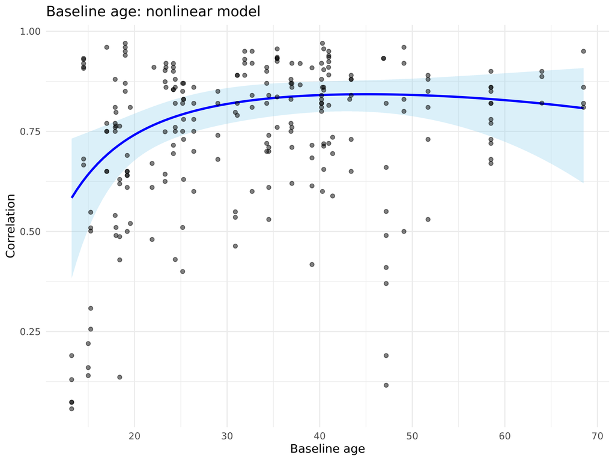

```r
# test moderation by baseline age
mod_age <- rma.mv(yi, vi,
                               random=list(~ 1 | es_id, ~ 1 | ref),
                               mods=~baseline_age,
                               data=data)

mod_age

# extract k studies with baseline age
k_age <- data %>%
  filter(!is.na(ES) & !is.na(baseline_age)) %>%
  group_by(ref) %>% # group by study reference
  dplyr::summarise(m = max(ref)) %>%  # select one row per study
  nrow() # count number of rows
# extract total sample size for studies with baseline age
n_age <- data %>%
  dplyr::filter(!is.na(baseline_age) & !is.na(ES)) %>%
  group_by(cohort) %>%
  dplyr::count(followup_n) %>%
  dplyr::summarise(m = max(followup_n)) %>%  print(n=100)%>%
  dplyr::summarise(n = sum(m))

# calculating the proportion of heterogeneity explained by moderators :

tau2_mod_age <- sum(mod_age$sigma2)

R2 <- (tau2_res - tau2_mod_age) / tau2_res

age_R2 <- R2 *100

# examine bubble plot
pdf(file.path(Figures, "06_bubble_baseline_age.pdf"), width = 8, height = 6)

regplot(
  mod_age,
  ylim = c(0, 1),
  xlab = "Baseline age",
  trans = transf.ztor,
  bg = "skyblue",
  main = "Baseline age"
)

dev.off()

## Add a log term as the relationship appears to be nonlinear

mod_age_nonlinear <- rma.mv(yi, vi,
                            random = list(~ 1 | es_id, ~ 1 | ref),
                            mods = ~ baseline_age + log(baseline_age),
                            data = data)

anova(mod_age, mod_age_nonlinear)

# Plot log model
# Generate a sequence of baseline ages for smooth plotting
age_seq <- seq(min(data$baseline_age, na.rm = TRUE),
               max(data$baseline_age, na.rm = TRUE),
               length.out = 100)

# Create the new moderator matrix
newmods_matrix <- cbind(age_seq, log(age_seq))

# Get predicted values (in Fisher's z) and apply the inverse transformation (Fisher's z → correlation)
preds <- predict(mod_age_nonlinear, newmods = newmods_matrix)

# Apply Fisher's z-to-r transformation
plot_data <- data.frame(
  baseline_age = age_seq,
  predicted_yi = transf.ztor(preds$pred),  # Convert to correlation scale
  ci_lb = transf.ztor(preds$ci.lb),  # Convert lower bound
  ci_ub = transf.ztor(preds$ci.ub)   # Convert upper bound
)

# Save the plot as a PNG
p_baseline_age_log <- ggplot(plot_data, aes(x = baseline_age, y = predicted_yi)) +
  geom_ribbon(aes(ymin = ci_lb, ymax = ci_ub), fill = "skyblue", alpha = 0.3) +
  geom_line(color = "blue", size = 1) +
  geom_point(data = data, aes(x = baseline_age, y = transf.ztor(yi)), alpha = 0.5) +
  labs(
    title = "Baseline age: nonlinear model",
    x = "Baseline age",
    y = "Correlation"
  ) +
  theme_minimal()

p_baseline_age_log
```

```r
ggsave(
  filename = file.path(Figures, "07_baseline_age_nonlinear.pdf"),
  plot = p_baseline_age_log,
  width = 8,
  height = 6
)

## Binary categorisation of baseline age

mod_age_bin <- rma.mv(yi, vi,
                               random=list(~ 1 | es_id, ~ 1 | ref),
                               mods=~baseline_age_binary,
                               data=data)
# extract meta-analytic effect sizes for binary age categories
mod_age_bin_spec <- rma.mv(yi, vi,
                                    random=list(~ 1 | es_id, ~ 1 | ref),
                                    mods=~baseline_age_binary-1,
                                    data=data)


res_tab <- coef(summary(mod_age_bin_spec))
cbind(
  estimate_r = transf.ztor(res_tab[, "estimate"]),
  ci_lb_r = transf.ztor(res_tab[, "ci.lb"]),
  ci_ub_r = transf.ztor(res_tab[, "ci.ub"])
)

# extract k studies
k_age_bin <- data %>%
  filter(!is.na(ES) & !is.na(baseline_age_binary)) %>%
  dplyr::count(ref, baseline_age_binary) %>%
  dplyr::group_by(baseline_age_binary) %>% dplyr::count(baseline_age_binary)
# extract total sample size
n_age_bin <- data %>%
  dplyr::filter(!is.na(baseline_age_binary) & !is.na(ES)) %>%
  group_by(baseline_age_binary, cohort) %>%
  dplyr::count(followup_n) %>%
  dplyr::summarise(m = max(followup_n)) %>%  print(n=100)%>%
  dplyr::summarise(n = sum(m))

# calculating the proportion of heterogeneity explained by moderator:

tau2_mod_age_bin <- sum(mod_age_bin$sigma2)

R2 <- (tau2_res - tau2_mod_age_bin) / tau2_res

age_bin_R2 <- R2 *100
age_bin_R2
```

### Multivariate model: baseline age and follow up interval

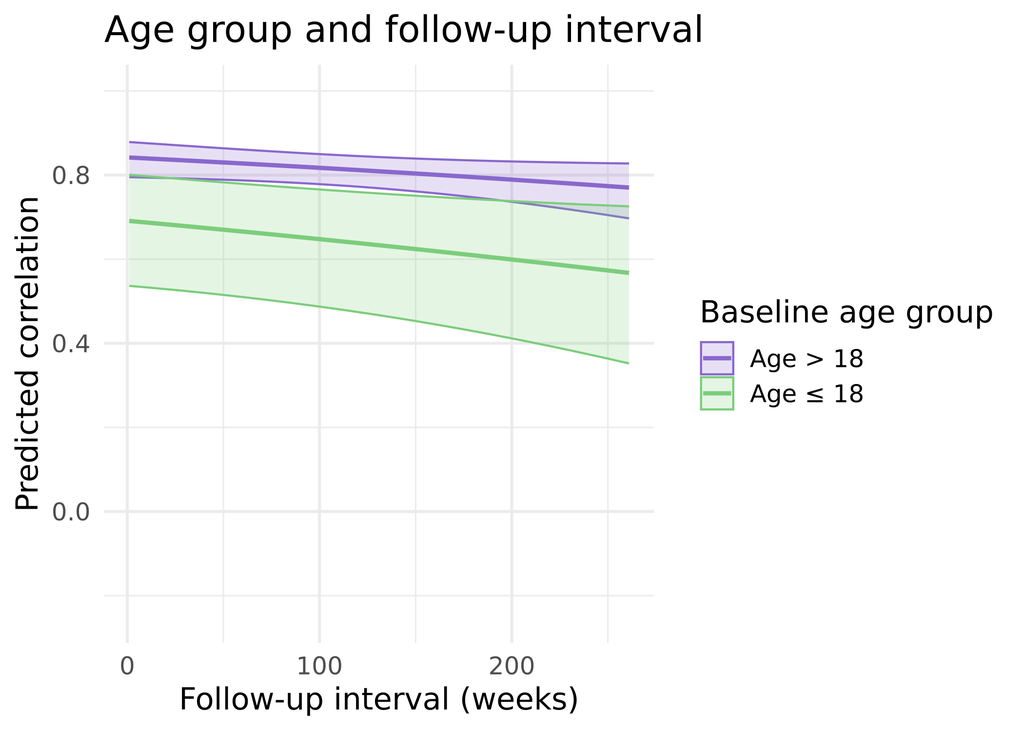

```r
# test moderation by baseline age & time interval
mod_age_time <- rma.mv(yi, vi,
                               random=list(~ 1 | es_id, ~ 1 | ref),
                               mods=~baseline_age_binary + followup_interval,
                               data=data)

summary(mod_age_time)

# Plot interaction model

# Create new data grid for prediction
new_data_1 <- expand.grid(
  baseline_age_binary = c(0, 1),           # 0 = Age ≤ 18, 1 = Age > 18
  followup_interval = 1:261                # Follow-up interval in weeks (up to 5 years)
)

# Generate predictor matrix (drop intercept)
X <- model.matrix(
  ~ baseline_age_binary + followup_interval,
  data = new_data_1
)[, -1]

# Predict from interaction model NOTE: still on z-scale
preds <- predict(mod_age_time, newmods = X)

# Add predicted values. ALso transform to correlation scale before plotting
new_data_1 <- new_data_1 %>%
  mutate(
    correlation = transf.ztor(preds$pred),
    ci_lower = transf.ztor(preds$ci.lb),
    ci_upper = transf.ztor(preds$ci.ub),
    age_group = ifelse(baseline_age_binary == 0, "Age ≤ 18", "Age > 18")
  )


p_age_time <- ggplot(new_data_1, aes(x = followup_interval, y = correlation, color = age_group, fill = age_group)) +
  geom_ribbon(aes(ymin = ci_lower, ymax = ci_upper), alpha = 0.2) +
  geom_line(size = 1) +
  scale_y_continuous(limits = c(-0.25, 1)) +
  scale_color_manual(values = c("Age > 18" = "mediumpurple3", "Age ≤ 18" = "palegreen3")) +
  scale_fill_manual(values = c("Age > 18" = "mediumpurple3", "Age ≤ 18" = "palegreen3")) +
  labs(
    title = "Age group and follow-up interval",
    x = "Follow-up interval (weeks)",
    y = "Predicted correlation",
    color = "Baseline age group",
    fill = "Baseline age group"
  ) +
  theme_minimal(base_size = 15)

p_age_time
```

```r
ggsave(
  filename = file.path(Figures, "08_age_group_followup_interval.pdf"),
  plot = p_age_time,
  width = 9,
  height = 6
)
```

### Interaction between baseline age and follow up interval

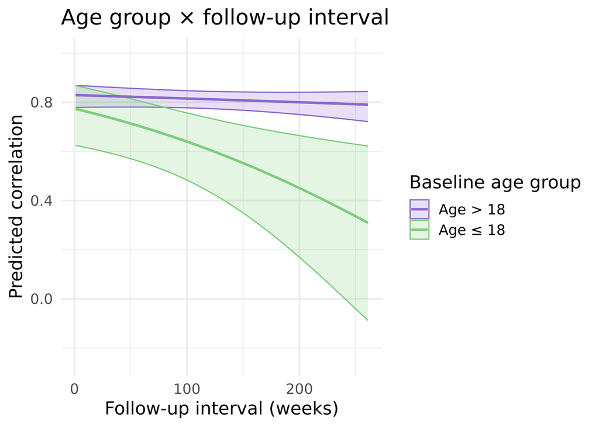

```r
# test interaction by baseline age & time interval
mod_age_interval <- rma.mv(yi, vi,
                               random=list(~ 1 | es_id, ~ 1 | ref),
                               mods=~baseline_age_binary + followup_interval + baseline_age_binary*followup_interval,
                               data=data)

summary(mod_age_interval)

tau2_mod_age_interval <- sum(mod_age_interval$sigma2)

R2 <- (tau2_res - tau2_mod_age_interval) / tau2_res

age_interval_R2 <- R2 *100
age_interval_R2

# Plot interaction model

# Create new data grid for prediction
new_data <- expand.grid(
  baseline_age_binary = c(0, 1),           # 0 = Age ≤ 18, 1 = Age > 18
  followup_interval = 1:261                # Follow-up interval in weeks (up to 5 years)
)

# Generate predictor matrix (drop intercept)
X <- model.matrix(
  ~ baseline_age_binary + followup_interval + baseline_age_binary * followup_interval,
  data = new_data
)[, -1]

# Predict from interaction model NOTE: still on z-scale
preds <- predict(mod_age_interval, newmods = X)

# Add predicted values. ALso transform to correlation scale before plotting
new_data <- new_data %>%
  mutate(
    correlation = transf.ztor(preds$pred),
    ci_lower = transf.ztor(preds$ci.lb),
    ci_upper = transf.ztor(preds$ci.ub),
    age_group = ifelse(baseline_age_binary == 0, "Age ≤ 18", "Age > 18")
  )

p_age_interval <- ggplot(new_data, aes(x = followup_interval, y = correlation, color = age_group, fill = age_group)) +
  geom_ribbon(aes(ymin = ci_lower, ymax = ci_upper), alpha = 0.2) +
  geom_line(size = 1) +
  scale_y_continuous(limits = c(-0.25, 1)) +
  scale_color_manual(values = c("Age > 18" = "mediumpurple3", "Age ≤ 18" = "palegreen3")) +
  scale_fill_manual(values = c("Age > 18" = "mediumpurple3", "Age ≤ 18" = "palegreen3")) +
  labs(
    title = "Age group × follow-up interval",
    x = "Follow-up interval (weeks)",
    y = "Predicted correlation",
    color = "Baseline age group",
    fill = "Baseline age group"
  ) +
  theme_minimal(base_size = 15)

p_age_interval
```

```r
ggsave(
  filename = file.path(Figures, "09_age_group_followup_interval_interaction.pdf"),
  plot = p_age_interval,
  width = 9,
  height = 6
)

# prediction for 2.5 years (131 weeks) and 5 years (161 weeks)

# Rows: (age_bin, interval, interaction)
newmods <- rbind(
  c(0, 131, 0),       # childhood/adolescence at 131w
  c(1, 131, 131),     # adulthood at 131w
  c(0, 261, 0),       # childhood/adolescence at 261w
  c(1, 261, 261)      # adulthood at 261w
)
colnames(newmods) <- c("baseline_age_binary", "followup_interval",
                       "baseline_age_binary:followup_interval")


pred <- predict(mod_age_interval, newmods = newmods)         # on model’s scale
# r (correlation)
pred_r <- predict(mod_age_interval, newmods = newmods, transf = transf.ztor)

pred_r
```

### Follow-up age

```r
# test moderation by follow up age
mod_followup_age <- rma.mv(yi, vi,
                               random=list(~ 1 | es_id, ~ 1 | ref),
                               mods=~followup_age,
                               data=data)

# extract k studies with follow up age
k_followup_age <- data %>%
  filter(!is.na(ES) & !is.na(followup_age)) %>%
  group_by(ref) %>% # group by study reference
  dplyr::summarise(m = max(ref)) %>%  # select one row per study
  nrow() # count number of rows
# extract total sample size for studies with follow up age
n_followup_age <- data %>%
  dplyr::filter(!is.na(followup_age) & !is.na(ES)) %>%
  group_by(cohort) %>%
  dplyr::count(followup_n) %>%
  dplyr::summarise(m = max(followup_n)) %>%  print(n=100)%>%
  dplyr::summarise(n = sum(m))

# calculating the proportion of heterogeneity explained by moderator:

tau2_mod_followup_age <- sum(mod_followup_age$sigma2)

R2 <- (tau2_res - tau2_mod_followup_age) / tau2_res

followup_age_R2 <- R2 *100

followup_age_R2

# examine bubble plot
pdf(file.path(Figures, "10_bubble_followup_age.pdf"), width = 8, height = 6)

regplot(
  mod_followup_age,
  ylim = c(0, 1),
  xlab = "Follow-up age",
  trans = transf.ztor,
  bg = "skyblue",
  main = "Follow-up age"
)

dev.off()
```

### Time interval

```r
mod_interval <- rma.mv(yi, vi, random=list(~ 1 | es_id, ~ 1 | ref),
                              mods=~ followup_interval, data=data)

# extract k studies with data on time interval
k_interval <- data %>%
  filter(!is.na(ES) & !is.na(followup_interval)) %>%
  group_by(ref) %>% # group by study reference
  dplyr::summarise(m = max(ref)) %>%  # select one row per study
  nrow() # count number of rows
# extract total sample size of studies with data on time interval
n_interval <- data %>%
  dplyr::filter(!is.na(followup_interval) & !is.na(ES)) %>%
  group_by(cohort) %>%
  dplyr::count(followup_n) %>%
  dplyr::summarise(m = max(followup_n)) %>%  print(n=100)%>%
  dplyr::summarise(n = sum(m))

# proportion of variance explained by moderator

tau2_mod_interval <- sum(mod_interval$sigma2)

R2 <- (tau2_res - tau2_mod_interval) / tau2_res

interval_R2 <- R2 *100

interval_R2

pdf(file.path(Figures, "11_bubble_followup_interval.pdf"), width = 8, height = 6)

regplot(
  mod_interval,
  ylim = c(0, 1),
  xlab = "Follow-up interval (weeks)",
  trans = transf.ztor,
  bg = "skyblue",
  main = "Follow-up interval"
)

dev.off()
```

### Attrition

```r
mod_attrition <- rma.mv(yi, vi, random=list(~ 1 | es_id, ~ 1 | ref),
                              mods=attrition, data=data)

mod_attrition

# extract k studies with attrtion rates
k_attrition <- data %>%
  filter(!is.na(ES) & !is.na(attrition)) %>%
  group_by(ref) %>% # group by study reference
  dplyr::summarise(m = max(ref)) %>%  # select one row per study
  nrow() # count number of rows
# extract total sample size for studies with attrition rates
n_attrition <- data %>%
  dplyr::filter(!is.na(attrition) & !is.na(ES)) %>%
  group_by(cohort) %>%
  dplyr::count(followup_n) %>%
  dplyr::summarise(m = max(followup_n)) %>%  print(n=100)%>%
  dplyr::summarise(n = sum(m))

#examine bubble plot
pdf(file.path(Figures, "12_bubble_attrition.pdf"), width = 8, height = 6)

regplot(
  mod_attrition,
  ylim = c(0, 1),
  xlab = "Attrition (%)",
  trans = transf.ztor,
  bg = "skyblue",
  main = "Attrition"
)

dev.off()

# calculating the proportion of heterogeneity explained by moderator:

tau2_mod_attrition <- sum(mod_attrition$sigma2)

R2 <- (tau2_res - tau2_mod_attrition) / tau2_res

attrition_R2 <- R2 *100
attrition_R2
```

### Study quality

```r
# test moderation by study quality
mod_quality <- rma.mv(yi, vi,
                               random=list(~ 1 | es_id, ~ 1 | ref),
                               mods=~q_total,
                               data=data)

mod_quality

# extract k studies with baseline age
k_quality <- data %>%
  filter(!is.na(ES) & !is.na(q_total)) %>%
  group_by(ref) %>% # group by study reference
  dplyr::summarise(m = max(ref)) %>%  # select one row per study
  nrow() # count number of rows
# extract total sample size for studies with baseline age
n_quality <- data %>%
  dplyr::filter(!is.na(q_total) & !is.na(ES)) %>%
  group_by(cohort) %>%
  dplyr::count(followup_n) %>%
  dplyr::summarise(m = max(followup_n)) %>%  print(n=100)%>%
  dplyr::summarise(n = sum(m))

# calculating the proportion of heterogeneity explained by moderators :

tau2_mod_quality <- sum(mod_quality$sigma2)

R2 <- (tau2_res - tau2_mod_quality) / tau2_res

quality_R2 <- R2 *100

quality_R2
```

### Clinical subset

```r
data$clinical <- ifelse(data$sample == 2, 1, 0)

# subset to only studies that include MH diagnosis
data_MH <- subset(data, !is.na(sample_mh))



dplyr::select(data, author, clinical, sample_mh)

res_MH <- rma.mv(yi, vi, random=list(~ 1 | es_id, ~ 1 | ref), data=data_MH)

res_MH

predict(res_MH, transf=transf.ztor, digits=2)

tau2_res_MH <- sum(res_MH$sigma2)

## not all studies 100% clinical sample, so first test for proportion diagnosis within clinical sample

# test moderation by proportion diagnosis
mod_prop_diag <- rma.mv(yi, vi,
                               random=list(~ 1 | es_id, ~ 1 | ref),
                               mods=~proportion_diagnosis,
                               data=data_MH)

mod_prop_diag

transf.ztor(mod_prop_diag$beta)
transf.ztor(mod_prop_diag$ci.lb)
transf.ztor(mod_prop_diag$ci.ub)

#examine plot
pdf(file.path(Figures, "13_bubble_proportion_diagnosed.pdf"), width = 8, height = 6)

regplot(
  mod_prop_diag,
  ylim = c(0, 1),
  xlab = "Proportion diagnosed",
  trans = transf.ztor,
  bg = "skyblue",
  main = "Proportion diagnosed"
)

dev.off()

# extract k studies with baseline age
k_prop_diag <- data_MH %>%
  filter(!is.na(ES) & !is.na(proportion_diagnosis)) %>%
  group_by(ref) %>% # group by study reference
  dplyr::summarise(m = max(ref)) %>%  # select one row per study
  nrow() # count number of rows
# extract total sample size for studies with baseline age
n_prop_diag <- data_MH %>%
  dplyr::filter(!is.na(proportion_diagnosis) & !is.na(ES)) %>%
  group_by(cohort) %>%
  dplyr::count(followup_n) %>%
  dplyr::summarise(m = max(followup_n)) %>%  print(n=100)%>%
  dplyr::summarise(n = sum(m))

tau2_mod_prop_diag <- sum(mod_prop_diag$sigma2)

R2 <- (tau2_res_MH - tau2_mod_prop_diag) / tau2_res_MH

prop_diag_R2 <- R2 *100

prop_diag_R2

# test moderation by type of MH diagnosis

table(data_MH$sample_mh)

mod_mh <- rma.mv(yi, vi,
                               random=list(~ 1 | es_id, ~ 1 | ref),
                               mods=~sample_mh,
                               data=data_MH)
# extract meta-analytic effect sizes for each type of child maltreatment
mod_mh_spec <- rma.mv(yi, vi,
                                    random=list(~ 1 | es_id, ~ 1 | ref),
                                    mods=~sample_mh-1,
                                    data=data_MH)

transf.ztor(mod_mh_spec$beta)

# extract k studies with diagnosis
k_diagnosis <- data %>%
  filter(!is.na(ES) & !is.na(sample_mh)) %>%
  dplyr::count(ref, sample_mh) %>%
  dplyr::group_by(sample_mh) %>% dplyr::count(sample_mh)
# extract total sample size for each diagnosis
n_diagnosis <- data %>%
  dplyr::filter(!is.na(sample_mh) & !is.na(ES)) %>%
  group_by(sample_mh, cohort) %>%
  dplyr::count(followup_n) %>%
  dplyr::summarise(m = max(followup_n)) %>%  print(n=100)%>%
  dplyr::summarise(n = sum(m))

tau2_diagnosis <- sum(mod_mh$sigma2)

R2 <- (tau2_res_MH - tau2_diagnosis) / tau2_res_MH

diagnosis_R2 <- R2 *100

diagnosis_R2

# test moderation by mental health intervention

table(data_MH$sample_intervention)

data_MH$sample_intervention <- factor(
  ifelse(data_MH$sample_intervention == 0, "no intervention", "intervention"))

table(data_MH$sample_intervention)

mod_intervention <- rma.mv(yi, vi,
                               random=list(~ 1 | es_id, ~ 1 | ref),
                               mods=~sample_intervention,
                               data=data_MH)
# extract meta-analytic effect sizes for each type of child maltreatment
mod_intervention_spec <- rma.mv(yi, vi,
                                    random=list(~ 1 | es_id, ~ 1 | ref),
                                    mods=~sample_intervention-1,
                                    data=data_MH)

# extract k studies with intervention
k_intervention <- data_MH %>%
  filter(!is.na(ES) & !is.na(sample_intervention)) %>%
  dplyr::count(ref, sample_intervention) %>%
  dplyr::group_by(sample_intervention) %>% dplyr::count(sample_intervention)
# extract total sample size for intervention
n_intervention <- data_MH %>%
  dplyr::filter(!is.na(sample_intervention) & !is.na(ES)) %>%
  group_by(sample_intervention, cohort) %>%
  dplyr::count(followup_n) %>%
  dplyr::summarise(m = max(followup_n)) %>%  print(n=100)%>%
  dplyr::summarise(n = sum(m))

tau2_intervention <- sum(mod_intervention$sigma2)

R2 <- (tau2_res_MH - tau2_intervention) / tau2_res_MH

intervention_R2 <- R2 *100

intervention_R2

## sensitivity analysis including only instances where sample is 100% clinical

data_all_clinical <- subset(data, proportion_diagnosis == 100)

res_all_clinical <- rma.mv(yi, vi, random=list(~ 1 | es_id, ~ 1 | ref), data=data_all_clinical)

res_all_clinical

predict(res_all_clinical, transf=transf.ztor, digits=2)

tau2_res_all_clinical <- sum(res_all_clinical$sigma2)

## repeat moderation analyses within this subset

# type of psychopathology

table(data_all_clinical$sample_mh)

mod_mh_all_clinical <- rma.mv(yi, vi,
                               random=list(~ 1 | es_id, ~ 1 | ref),
                               mods=~sample_mh,
                               data=data_all_clinical)
# extract meta-analytic effect sizes for each type of child maltreatment
mod_mh_all_clinical_spec <- rma.mv(yi, vi,
                                    random=list(~ 1 | es_id, ~ 1 | ref),
                                    mods=~sample_mh-1,
                                    data=data_all_clinical)

transf.ztor(mod_mh_all_clinical_spec$beta)
transf.ztor(mod_mh_all_clinical_spec$ci.lb)
transf.ztor(mod_mh_all_clinical_spec$ci.ub)


# extract k studies with diagnosis
k_diagnosis_all <- data_all_clinical %>%
  filter(!is.na(ES) & !is.na(sample_mh)) %>%
  dplyr::count(ref, sample_mh) %>%
  dplyr::group_by(sample_mh) %>% dplyr::count(sample_mh)
# extract total sample size for each diagnosis
n_diagnosis_all <- data_all_clinical %>%
  dplyr::filter(!is.na(sample_mh) & !is.na(ES)) %>%
  group_by(sample_mh, cohort) %>%
  dplyr::count(followup_n) %>%
  dplyr::summarise(m = max(followup_n)) %>%  print(n=100)%>%
  dplyr::summarise(n = sum(m))

k_diagnosis_all
n_diagnosis_all

tau2_diagnosis_all <- sum(mod_mh_all_clinical$sigma2)

R2 <- (tau2_res_all_clinical - tau2_diagnosis_all) / tau2_res_all_clinical

diagnosis_all_R2 <- R2 *100

diagnosis_all_R2

# intervention

table(data_all_clinical$sample_intervention)

data_all_clinical$sample_intervention <- factor(
  ifelse(data_all_clinical$sample_intervention == 0, "no intervention", "intervention"))

mod_intervention_all_clinical <- rma.mv(yi, vi,
                               random=list(~ 1 | es_id, ~ 1 | ref),
                               mods=~sample_intervention,
                               data=data_all_clinical)
# extract meta-analytic effect sizes for each type of child maltreatment
mod_intervention_all_clinical_spec <- rma.mv(yi, vi,
                                    random=list(~ 1 | es_id, ~ 1 | ref),
                                    mods=~sample_intervention-1,
                                    data=data_all_clinical)

transf.ztor(mod_intervention_all_clinical_spec$beta)
transf.ztor(mod_intervention_all_clinical_spec$ci.lb)
transf.ztor(mod_intervention_all_clinical_spec$ci.ub)

# extract k studies with intervention
k_intervention_all <- data_all_clinical %>%
  filter(!is.na(ES) & !is.na(sample_intervention)) %>%
  dplyr::count(ref, sample_intervention) %>%
  dplyr::group_by(sample_intervention) %>% dplyr::count(sample_intervention)
# extract total sample size for intervention
n_intervention_all <- data_all_clinical %>%
  dplyr::filter(!is.na(sample_intervention) & !is.na(ES)) %>%
  group_by(sample_intervention, cohort) %>%
  dplyr::count(followup_n) %>%
  dplyr::summarise(m = max(followup_n)) %>%  print(n=100)%>%
  dplyr::summarise(n = sum(m))

k_intervention_all
n_intervention_all

# r-squared
tau2_intervention_all <- sum(mod_intervention_all_clinical$sigma2)

R2 <- (tau2_res_all_clinical - tau2_intervention_all) / tau2_res_all_clinical

intervention_all_R2 <- R2 *100

intervention_all_R2
```

## Create tables with main moderation results

Here we create a table showing the moderation results. First we define a function to input all of the results into the table, before collating all the results and generating the table.

#### Define function to make moderation table

```r
# Define function to combine effect estimates and CIs into a single cell for the table
paste_res <- function(est, lowCI, upCI) {
  mapply(function(e, l, u) {
    if (any(is.na(c(e, l, u)))) {
      return("")
    } else {
      return(paste0(format(round(e, 2), nsmall = 2),
                    " (",
                    format(round(l, 2), nsmall = 2),
                    "-",
                    format(round(u, 2), nsmall = 2),
                    ")"))
    }
  }, est, lowCI, upCI, USE.NAMES = FALSE)
}

## Make a function collating all the moderation results  ahead of making table
moderation_res <- function(k_mal_type, k_measure, k_sample, k_sex, k_age,
                           k_followup_age, k_interval,  k_attrition, k_quality,
                           n_mal_type, n_measure, n_sample, n_sex, n_age,
                           n_followup_age, n_interval , n_attrition, n_quality,
                           n_es_mal_type, n_es_measure, n_es_sample, n_es_sex, n_es_age,
                           n_es_followup_age, n_es_interval, n_es_attrition, n_es_quality,
                           mod_mal_type, mod_mal_type_spec,
                           mod_measure, mod_measure_spec,
                           mod_sample, mod_sample_spec,
                           mod_sex,
                           mod_age,
                           mod_followup_age,
                           mod_interval,
                           mod_attrition,
                           mod_quality,
                           mal_type_R2, measure_R2, sample_R2, sex_R2, age_R2,
                           followup_age_R2, interval_R2, attrition_R2, quality_R2)

 {

  # Make variable with moderator type and level
  mod_type <- c("Type of maltreatment", # type of maltreatment
                "ACEs",
                "Emotional abuse",
                "Emotional neglect",
                "Maltreatment",
                "Physical abuse",
                "Physical neglect",
                "Sexual abuse",
                "Measure type",# measure type
                "Interview",
                "Questionnaire",
                "Sample type", #sample type
                "Population representative",
                "Convenience",
                "Clinical",
                "Sex distribution (% female)", # sex
                "Baseline age", # baseline age
                "Follow-up age", # follow up age
                "Time interval (years)", # time interval
                "Loss to attrition (%)",# attrition
                "Quality") #quality check


 # Make variable summarising the k studies for each moderator/moderator category
  k <- as.vector(unlist(c(NA, k_mal_type[c(1,2,3,4,5,6,7),2],# type of maltreatment (ace, emotional abuse, emotional neglect, mt, physical abuse, physical neglect, sexual abuse)
                          NA, k_measure[c(1,2),2], # measure type (interview, questionnaire)
                          NA, k_sample[c(1,2,3),2],
                          k_sex, # sex
                          k_age, # baseline age
                          k_followup_age,
                          k_interval, # time interval
                          k_attrition, #attrition
                          k_quality)))

  # Make variable summarising the sample size for each moderator/moderator category

  n <- as.vector(unlist(c(NA, n_mal_type[c(1,2,3,4,5,6,7),2],# type of maltreatment (ace, emotional abuse, emotional neglect, mt, physical abuse, physical neglect, sexual abuse)
                          NA, n_measure[c(1,2),2], # measure type (interview, questionnaire)
                          NA, n_sample[c(1,2,3),2],
                          n_sex, # sex
                          n_age, # baseline age
                          n_followup_age,
                          n_interval, # time interval
                          n_attrition, #attrition
                          n_quality)))


  # Make variable summarising the number of effect sizes for each moderator/moderator category
  n_es <- as.vector(unlist(c(NA, n_es_mal_type[c(1,2,3,4,5,6,7)],# type of maltreatment (ace, emotional abuse, emotional neglect, mt, physical abuse, physical neglect, sexual abuse)
                          NA, n_es_measure[c(1,2)], # measure type (interview, questionnaire)
                          NA, n_es_sample[c(1,2,3)],
                          n_es_sex, # sex
                          n_es_age, # baseline age
                          n_es_followup_age,
                          n_es_interval, # time interval
                          n_es_attrition, #attrition
                          n_es_quality)))

# Make variable summarising the effect sizes for each moderator/moderator category
  ES <- c(NA, transf.ztor(mod_mal_type_spec$beta[c(1,2,3,4,5,6,7)]),# type of maltreatment (ace, emotional abuse, emotional neglect, mt, physical abuse, physical neglect, sexual abuse))
          NA, transf.ztor(mod_measure_spec$beta[c(1,2)]),
          NA, transf.ztor(mod_sample_spec$beta[c(1,2,3)]),
          transf.ztor(mod_sex$beta[2]),
          transf.ztor(mod_age$beta[2]),
          transf.ztor(mod_followup_age$beta[2]),
          transf.ztor(mod_interval$beta[2]),
          transf.ztor(mod_attrition$beta[2]),
          transf.ztor(mod_quality$beta[2]))

 # Make variable summarising the lower CI for each moderator/moderator category
  lowCI <- c(NA, transf.ztor(mod_mal_type_spec$ci.lb[c(1,2,3,4,5,6,7)]),
              NA, transf.ztor(mod_measure_spec$ci.lb[c(1,2)]),
          NA, transf.ztor(mod_sample_spec$ci.lb[c(1,2,3)]),
          transf.ztor(mod_sex$ci.lb[2]),
          transf.ztor(mod_age$ci.lb[2]),
          transf.ztor(mod_followup_age$ci.lb[2]),
          transf.ztor(mod_interval$ci.lb[2]),
          transf.ztor(mod_attrition$ci.lb[2]),
          transf.ztor(mod_quality$ci.lb[2]))

  # Make variable summarising the upper CI for each moderator/moderator category
 upCI <- c(NA,transf.ztor(mod_mal_type_spec$ci.ub[c(1,2,3,4,5,6,7)]),
            NA, transf.ztor(mod_measure_spec$ci.ub[c(1,2)]),
          NA, transf.ztor(mod_sample_spec$ci.ub[c(1,2,3)]),
          transf.ztor(mod_sex$ci.ub[2]),
          transf.ztor(mod_age$ci.ub[2]),
          transf.ztor(mod_followup_age$ci.ub[2]),
          transf.ztor(mod_interval$ci.ub[2]),
          transf.ztor(mod_attrition$ci.ub[2]),
          transf.ztor(mod_quality$ci.ub[2]))


 # Make variable summarising the Q_moderation statistic for each moderator
  Q_mod <- c(mod_mal_type$QM,
             NA, NA, NA, NA, NA, NA, NA, #7 types of MT listed
             mod_measure$QM,
             NA, NA,
             mod_sample$QM,
             NA, NA, NA,
             mod_sex$QM,
             mod_age$QM,
             mod_followup_age$QM,
             mod_interval$QM,
             mod_attrition$QM,
             mod_quality$QM)

 # Make variable summarising the p-value for each moderator
  p <- c(mod_mal_type$QMp,
             NA, NA, NA, NA, NA, NA, NA, #7 types of MT listed
             mod_measure$QMp,
             NA, NA,
             mod_sample$QMp,
             NA, NA, NA,
             mod_sex$QMp,
             mod_age$QMp,
             mod_followup_age$QMp,
             mod_interval$QMp,
             mod_attrition$QMp,
             mod_quality$QMp)

  # Make variable summarising R^2

 R2 <- c(mal_type_R2,
             NA, NA, NA, NA, NA, NA, NA, #7 types of MT listed
             measure_R2,
             NA, NA,
             sample_R2,
             NA, NA, NA,
             sex_R2,
             age_R2,
             followup_age_R2,
             interval_R2,
             attrition_R2,
             quality_R2)


# Collate results into dataframe
  mod <- as.data.frame(cbind(mod_type, k, n, n_es,
                             format(round(ES, 2), nsmall=2),
                                       format(round(lowCI, 2), nsmall=2),
                                       format(round(upCI, 2), nsmall=2),
                                       format(round(Q_mod, 2), nsmall=2),
                                       format(round(p, 3), nsmall=3),
                                       format(round(R2, 2), nsmall=2)))

colnames(mod) <- c("Moderator", "k","n", "n_es", "OR", "Low_CI", "Up_CI", "Q_mod", "p_value", "R^2")

    ## Convert variables to numeric
  cols.num <- c( "n", "OR", "Low_CI", "Up_CI", "Q_mod", "p_value", "R^2")
  mod[cols.num] <- sapply(mod[cols.num],as.numeric)

  ## Create new variable with OR and CIs pasted into one
  mod$ES_CI <- paste_res(mod$OR, mod$Low_CI, mod$Up_CI)


  # Condense table
  mod_table <- subset(mod, select=c("Moderator", "k", "n", "n_es", "ES_CI", "Q_mod", "p_value", "R^2"))

   return(mod_table)
}
```

```r
options(knitr.kable.NA = '') # ensure kable does not print NAs

## Make moderation table
moderation_result <- moderation_res(k_mal_type, k_measure, k_sample, k_sex, k_age,
                           k_followup_age, k_interval,  k_attrition, k_quality,
                           n_mal_type, n_measure, n_sample, n_sex, n_age,
                           n_followup_age, n_interval , n_attrition, n_quality,
                           table(data$exposure_type[!is.na(data$ES)]),
                           table(data$baseline_measure_type[!is.na(data$ES)]),
                           table(data$sample[!is.na(data$ES)]),
                           length(data$percent_female[!is.na(data$percent_female)
                                                      & !is.na(data$ES)]),
                           length(data$baseline_age[!is.na(data$baseline_age)
                                                    & !is.na(data$ES)]),
                           length(data$followup_age[!is.na(data$followup_age)
                                                     & !is.na(data$ES)]),
                           length(data$followup_interval[!is.na(data$followup_interval)
                                                               & !is.na(data$ES)]),
                           length(data$q_attrition[!is.na(data$q_attrition)
                                                   & !is.na(data$ES)]),
                           length(data$q_total[!is.na(data$q_total)
                                                   & !is.na(data$ES)]),
                           mod_mal_type,
                           mod_mal_type_spec,
                           mod_measure,
                           mod_measure_spec,
                           mod_sample,
                           mod_sample_spec,
                           mod_sex,
                           mod_age,
                           mod_followup_age,
                           mod_interval,
                           mod_attrition,
                           mod_quality,
                           mal_type_R2,
                           measure_R2,
                           sample_R2,
                           sex_R2,
                           age_R2,
                           followup_age_R2,
                           interval_R2,
                           attrition_R2,
                           quality_R2)




moderation_result_clean <- moderation_result %>%
  mutate(across(everything(), ~ ifelse(. %in% c(NA, "NA"), "", .)))

# Save the table as an HTML file with NA values displayed as blank spaces
# Save table as CSV
write.csv(
  moderation_result_clean,
  file = file.path(Tables, "moderation_results.csv"),
  row.names = FALSE
)

# Create formatted HTML table
moderation_table_html <- kable(
  moderation_result_clean,
  row.names = FALSE,
  col.names = c("Moderator", "k", "N", "No. ES", "r (95% CI)", "Q_mod", "p-value", "R^2")
) %>%
  kable_styling(font_size = 11) %>%
  add_indent(positions = c(2:8, 10:11, 13:15))

# Save formatted HTML table
cat(
  as.character(moderation_table_html),
  file = file.path(Tables, "moderation_results.html")
)

# Print table in knitted report
moderation_table_html
```

| Moderator | k | N | No. ES | r (95% CI) | Q_mod | p-value | R^2 |
| --- | --- | --- | --- | --- | --- | --- | --- |
| Type of maltreatment |  |  |  |  | 25.83 | 0 | 1.61 |
| ACEs | 5 | 8371 | 7 | 0.81 (0.70-0.88) |  |  |  |
| Emotional abuse | 32 | 11755 | 40 | 0.79 (0.74-0.84) |  |  |  |
| Emotional neglect | 22 | 5029 | 27 | 0.75 (0.67-0.81) |  |  |  |
| Maltreatment | 16 | 4977 | 23 | 0.81 (0.75-0.86) |  |  |  |
| Physical abuse | 42 | 17723 | 54 | 0.81 (0.77-0.85) |  |  |  |
| Physical neglect | 24 | 6221 | 31 | 0.69 (0.60-0.76) |  |  |  |
| Sexual abuse | 42 | 27523 | 53 | 0.81 (0.76-0.85) |  |  |  |
| Measure type |  |  |  |  | 0.07 | 0.793 | -1.48 |
| Interview | 8 | 5315 | 32 | 0.78 (0.65-0.86) |  |  |  |
| Questionnaire | 41 | 33067 | 203 | 0.79 (0.75-0.83) |  |  |  |
| Sample type |  |  |  |  | 11.54 | 0.003 | 12.11 |
| Population representative | 9 | 29218 | 30 | 0.62 (0.46-0.74) |  |  |  |
| Convenience | 18 | 6526 | 78 | 0.81 (0.74-0.86) |  |  |  |
| Clinical | 22 | 2588 | 127 | 0.83 (0.78-0.87) |  |  |  |
| Sex distribution (% female) | 48 | 38281 | 233 | 0.00 (0.00-0.00) | 3.2 | 0.074 | 1.66 |
| Baseline age | 48 | 30866 | 234 | 0.01 (0.00-0.02) | 7.02 | 0.008 | 7.7 |
| Follow-up age | 48 | 30866 | 234 | 0.01 (0.00-0.01) | 4.59 | 0.032 | 4.61 |
| Time interval (years) | 49 | 38332 | 235 | 0.00 (0.00-0.00) | 2.96 | 0.085 | 2.81 |
| Loss to attrition (%) | 49 | 38332 | 235 | 0.00 (0.00-0.01) | 2.05 | 0.152 | 2.29 |
| Quality | 49 | 38332 | 235 | -0.08 (-0.19-0.03) | 1.97 | 0.161 | 1.51 |

## Create tables with clinical moderation results

#### Define function to make clinical subset moderation table

```r
# Define function to combine effect estimates and CIs into a single cell for the table
# Define function to combine effect estimates and CIs into a single cell for the table
paste_res <- function(est, lowCI, upCI) {
  mapply(function(e, l, u) {
    if (any(is.na(c(e, l, u)))) {
      return("")
    } else {
      return(paste0(format(round(e, 2), nsmall = 2),
                    " (",
                    format(round(l, 2), nsmall = 2),
                    "-",
                    format(round(u, 2), nsmall = 2),
                    ")"))
    }
  }, est, lowCI, upCI, USE.NAMES = FALSE)
}


## Make a function collating all the moderation results  ahead of making table
clinical_moderation_res <- function(k_prop_diag, k_diagnosis, k_intervention,
                           n_prop_diag, n_diagnosis, n_intervention,
                           n_es_prop_diag, n_es_diagnosis, n_es_intervention,
                           mod_prop_diag,
                           mod_mh, mod_mh_spec,
                           mod_intervention, mod_intervention_spec,
                           prop_diag_R2, diagnosis_R2, intervention_R2)

 {

  # Make variable with moderator type and level
  mod_type <- c("Proportion diagnosis",
                "Diagnosis",
                "Addiction",
                "Bipolar",
                "Depression",
                "General",
                "Personality Disorder",
                "Psychosis",
                "PTSD",
                "Intervention",
                "Intervention",
                "No intervention")



 # Make variable summarising the k studies for each moderator/moderator category
  k <- as.vector(unlist(c(k_prop_diag,
                          NA, k_diagnosis[c(1,2,3,4,5,6,7),2],
                          NA, k_intervention[c(1,2),2])))



  # Make variable summarising the sample size for each moderator/moderator category

  n <- as.vector(unlist(c(n_prop_diag,
                          NA, n_diagnosis[c(1,2,3,4,5,6,7),2], # measure type (interview, questionnaire)
                          NA, n_intervention[c(1,2),2])))



  # Make variable summarising the number of effect sizes for each moderator/moderator category
  n_es <- as.vector(unlist(c(n_es_prop_diag,
                          NA, n_es_diagnosis[c(1,2,3,4,5,6,7)],
                          NA, n_es_intervention[c(1,2)])))


# Make variable summarising the effect sizes for each moderator/moderator category
 ES <- c(transf.ztor(mod_prop_diag$beta[2]),
        NA,
        transf.ztor(mod_mh_spec$beta[c(1,2,3,4,5,6,7)]),
        NA,
        transf.ztor(mod_intervention_spec$beta[c(1,2)]))

lowCI <- c(transf.ztor(mod_prop_diag$ci.lb[2]),
           NA,
           transf.ztor(mod_mh_spec$ci.lb[c(1,2,3,4,5,6,7)]),
           NA,
           transf.ztor(mod_intervention_spec$ci.lb[c(1,2)]))

upCI <- c(transf.ztor(mod_prop_diag$ci.ub[2]),
          NA,
          transf.ztor(mod_mh_spec$ci.ub[c(1,2,3,4,5,6,7)]),
          NA,
          transf.ztor(mod_intervention_spec$ci.ub[c(1,2)]))

 # Make variable summarising the Q_moderation statistic for each moderator
  Q_mod <- c(mod_prop_diag$QM, #7 types of MT listed
             mod_mh$QM,
             NA, NA, NA, NA, NA, NA, NA,
             mod_intervention$QM,
             NA, NA)

 # Make variable summarising the p-value for each moderator
  p <- c(mod_prop_diag$QMp,
             mod_mh$QMp,
             NA, NA, NA, NA, NA, NA, NA,
             mod_intervention$QMp,
             NA, NA)

  # Make variable summarising R^2

 R2 <- c(prop_diag_R2,
             diagnosis_R2,
             NA, NA, NA, NA, NA, NA, NA,
             intervention_R2,
             NA, NA)


# Collate results into dataframe
  mod <- as.data.frame(cbind(mod_type, k, n, n_es,
                             format(round(ES, 2), nsmall=2),
                                       format(round(lowCI, 2), nsmall=2),
                                       format(round(upCI, 2), nsmall=2),
                                       format(round(Q_mod, 2), nsmall=2),
                                       format(round(p, 3), nsmall=3),
                                       format(round(R2, 2), nsmall=2)))

colnames(mod) <- c("Moderator", "k","n", "n_es", "OR", "Low_CI", "Up_CI", "Q_mod", "p_value", "R^2")

    ## Convert variables to numeric
  cols.num <- c( "n", "OR", "Low_CI", "Up_CI", "Q_mod", "p_value", "R^2")
  mod[cols.num] <- sapply(mod[cols.num],as.numeric)

  ## Create new variable with OR and CIs pasted into one
  mod$ES_CI <- paste_res(mod$OR, mod$Low_CI, mod$Up_CI)

  # Condense table
  mod_table_clinical <- subset(mod, select=c("Moderator", "k", "n", "n_es", "ES_CI", "Q_mod", "p_value", "R^2"))


   return(mod_table_clinical)
}
```

```r
options(knitr.kable.NA = '') # ensure kable does not print NAs
## Make moderation table for clinical subset
clinical_moderation_result <- clinical_moderation_res(k_prop_diag, k_diagnosis, k_intervention,
                           n_prop_diag, n_diagnosis, n_intervention,
                           length(data_MH$proportion_diagnosis[!is.na(data_MH$ES)]),
                           table(data_MH$sample_mh[!is.na(data_MH$ES)]),
                           table(data_MH$sample_intervention[!is.na(data_MH$ES)]),
                           mod_prop_diag,
                           mod_mh,
                           mod_mh_spec,
                           mod_intervention,
                           mod_intervention_spec,
                           prop_diag_R2,
                           diagnosis_R2,
                           intervention_R2)



clinical_moderation_result_clean <- clinical_moderation_result %>%
  mutate(across(everything(), ~ ifelse(is.na(.), "", .))) ##format to get rid of NA's



# Save table as CSV
write.csv(
  clinical_moderation_result_clean,
  file = file.path(Tables, "clinical_moderation_results.csv"),
  row.names = FALSE
)

# Create formatted HTML table
clinical_moderation_table_html <- kable(
  clinical_moderation_result_clean,
  row.names = FALSE,
  col.names = c("Moderator", "k", "N", "No. ES", "r (95% CI)", "Q_mod", "p-value", "R^2")
) %>%
  kable_styling(font_size = 11) %>%
  add_indent(positions = c(3:9, 11:12))

# Save formatted HTML table
cat(
  as.character(clinical_moderation_table_html),
  file = file.path(Tables, "clinical_moderation_results.html")
)

# Print table in knitted report
clinical_moderation_table_html
```

| Moderator | k | N | No. ES | r (95% CI) | Q_mod | p-value | R^2 |
| --- | --- | --- | --- | --- | --- | --- | --- |
| Proportion diagnosis | 22 | 2588 | 127 | 0.00 (0.00-0.00) | 0.1 | 0.754 | -1.31 |
| Diagnosis |  |  |  |  | 0.42 | 0.999 | -17.38 |
| Addiction | 1 | 100 | 6 | 0.83 (0.56-0.94) |  |  |  |
| Bipolar | 1 | 40 | 17 | 0.80 (0.68-0.88) |  |  |  |
| Depression | 3 | 109 | 32 | 0.83 (0.73-0.89) |  |  |  |
| General | 5 | 1369 | 22 | 0.83 (0.72-0.89) |  |  |  |
| Personality Disorder | 5 | 383 | 8 | 0.85 (0.72-0.92) |  |  |  |
| Psychosis | 3 | 399 | 37 | 0.82 (0.73-0.88) |  |  |  |
| PTSD | 5 | 205 | 5 | 0.83 (0.56-0.94) |  |  |  |
| Intervention |  |  |  |  | 0.3 | 0.584 | 0 |
| Intervention | 6 | 570 | 28 | 0.84 (0.78-0.88) |  |  |  |
| No intervention | 17 | 2018 | 99 | 0.82 (0.78-0.85) |  |  |  |

## Sensitivity analysis

Here we will conduct the following sensitivity analysis * excluding studies with participants under 18 which are unclear about whether exactly the same time frame is being measured * exclude studies where tetrachoric correlations were estimated by the calibration model * alternative age cut-off moderation analyses at age 21 and age 24 * repeat alternative age cut-off moderation analyses at age 21 and age 24 after excluding the two studies with unclear time comparison

### Excluding studies participants under 18 which are unclear about whether the same time frame is being measured (Breton & Park)

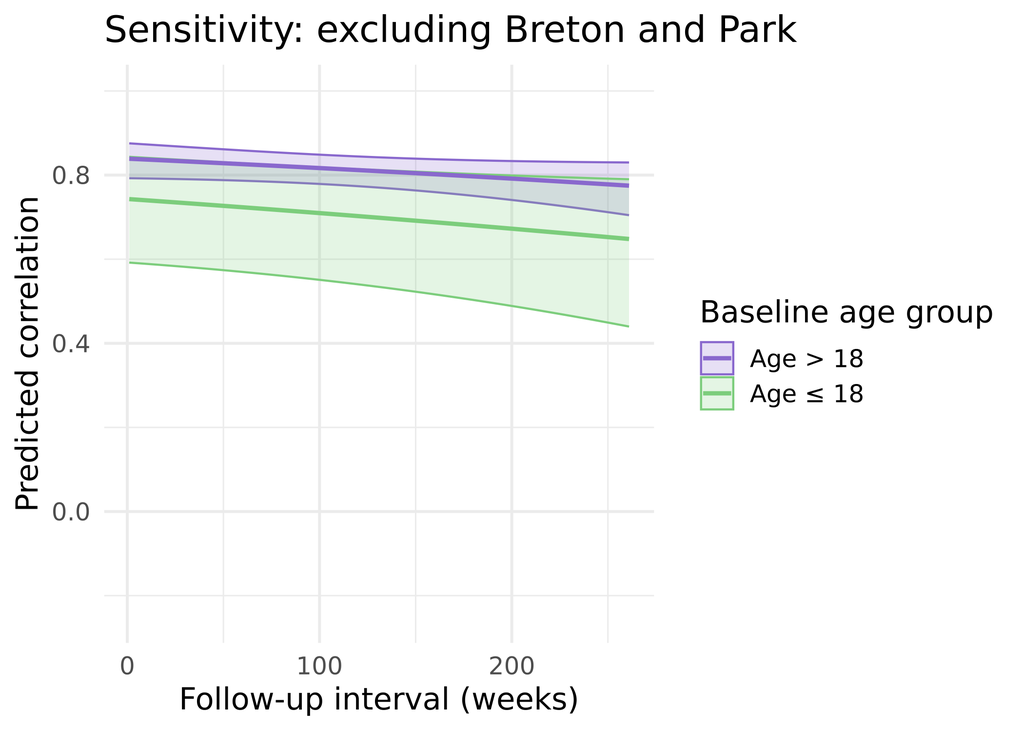

```r
data_excl <- subset(data, !(author %in% c("Breton", "Park")))

res_excl <- rma.mv(yi, vi, random=list(~ 1 | es_id, ~ 1 | ref), data=data_excl)

transf.ztor(res_excl$beta)
transf.ztor(res_excl$ci.lb)
transf.ztor(res_excl$ci.ub)

# moderation by baseline age - repeat for sensitivity analysis

mod_age_excl <- rma.mv(yi, vi,
                               random=list(~ 1 | es_id, ~ 1 | ref),
                               mods=~baseline_age_binary,
                               data=data_excl)

mod_age_excl_spec <- rma.mv(yi, vi,
                                    random=list(~ 1 | es_id, ~ 1 | ref),
                                    mods=~baseline_age_binary-1,
                                    data=data_excl)

transf.ztor(mod_age_excl_spec$beta)
transf.ztor(mod_age_excl_spec$ci.lb)
transf.ztor(mod_age_excl_spec$ci.ub)

# extract k studies with binary age
k_age_bin_excl <- data_excl %>%
  filter(!is.na(ES) & !is.na(baseline_age_binary)) %>%
  dplyr::count(ref, baseline_age_binary) %>%
  dplyr::group_by(baseline_age_binary) %>% dplyr::count(baseline_age_binary)
# extract total sample size for each age bin
n_age_bin_excl <- data_excl %>%
  dplyr::filter(!is.na(baseline_age_binary) & !is.na(ES)) %>%
  group_by(baseline_age_binary, cohort) %>%
  dplyr::count(followup_n) %>%
  dplyr::summarise(m = max(followup_n)) %>%  print(n=100)%>%
  dplyr::summarise(n = sum(m))

table(data_excl$baseline_age_binary)

tau2_mod_age_excl <- sum(mod_age_excl$sigma2)

R2 <- (tau2_res - tau2_mod_age_excl) / tau2_res

age_excl_R2 <- R2 *100
age_excl_R2


# multivariate
# test moderation by baseline age & time interval
mod_age_time_excl <- rma.mv(yi, vi,
                               random=list(~ 1 | es_id, ~ 1 | ref),
                               mods=~baseline_age_binary + followup_interval,
                               data=data_excl)

summary(mod_age_time_excl)


# Plot  model

# Create new data grid for prediction
new_data_1 <- expand.grid(
  baseline_age_binary = c(0, 1),           # 0 = Age ≤ 18, 1 = Age > 18
  followup_interval = 1:261                # Follow-up interval in weeks (up to 5 years)
)

# Generate predictor matrix (drop intercept)
X <- model.matrix(
  ~ baseline_age_binary + followup_interval,
  data = new_data_1
)[, -1]

# Predict from interaction model NOTE: still on z-scale
preds <- predict(mod_age_time_excl, newmods = X)

# Add predicted values. ALso transform to correlation scale before plotting
new_data_1 <- new_data_1 %>%
  mutate(
    correlation = transf.ztor(preds$pred),
    ci_lower = transf.ztor(preds$ci.lb),
    ci_upper = transf.ztor(preds$ci.ub),
    age_group = ifelse(baseline_age_binary == 0, "Age ≤ 18", "Age > 18")
  )

p_age_time_excl <- ggplot(new_data_1, aes(x = followup_interval, y = correlation, color = age_group, fill = age_group)) +
  geom_ribbon(aes(ymin = ci_lower, ymax = ci_upper), alpha = 0.2) +
  geom_line(size = 1) +
  scale_y_continuous(limits = c(-0.25, 1)) +
  scale_color_manual(values = c("Age > 18" = "mediumpurple3", "Age ≤ 18" = "palegreen3")) +
  scale_fill_manual(values = c("Age > 18" = "mediumpurple3", "Age ≤ 18" = "palegreen3")) +
  labs(
    title = "Sensitivity: excluding Breton and Park",
    x = "Follow-up interval (weeks)",
    y = "Predicted correlation",
    color = "Baseline age group",
    fill = "Baseline age group"
  ) +
  theme_minimal(base_size = 15)

p_age_time_excl
```

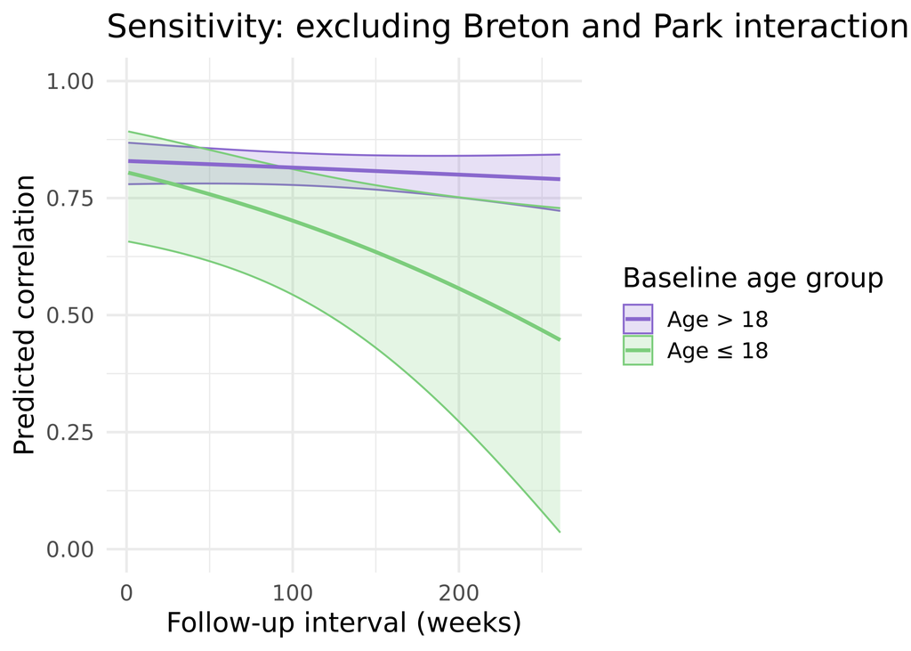

```r
ggsave(
  filename = file.path(Figures, "14_sensitivity_breton_park_age_time.pdf"),
  plot = p_age_time_excl,
  width = 9,
  height = 6
)


# interaction by baseline age & follow up interval - repeat for sensitivity analysis
mod_age_interval_excl <- rma.mv(yi, vi,
                               random=list(~ 1 | es_id, ~ 1 | ref),
                               mods=~baseline_age_binary + followup_interval + baseline_age_binary*followup_interval,
                               data=data_excl)

summary(mod_age_interval_excl)

tau2_mod_age_interval_excl <- sum(mod_age_interval_excl$sigma2)

R2 <- (tau2_res - tau2_mod_age_interval_excl) / tau2_res

age_interval_excl_R2 <- R2 *100
age_interval_excl_R2

#plot

# Create new data grid for prediction
new_data1 <- expand.grid(
  baseline_age_binary = c(0, 1),           # 0 = Age ≤ 18, 1 = Age > 18
  followup_interval = 1:261                # Follow-up interval in weeks (up to 5 years)
)

# Generate predictor matrix (drop intercept)
X <- model.matrix(
  ~ baseline_age_binary + followup_interval + baseline_age_binary * followup_interval,
  data = new_data1
)[, -1]

# Predict from interaction model NOTE: still on z-scale
preds <- predict(mod_age_interval_excl, newmods = X)

# Add predicted values. Also transform to correlation scale before plotting
new_data1 <- new_data1 %>%
  mutate(
    correlation = transf.ztor(preds$pred),
    ci_lower = transf.ztor(preds$ci.lb),
    ci_upper = transf.ztor(preds$ci.ub),
    age_group = ifelse(baseline_age_binary == 0, "Age ≤ 18", "Age > 18")
  )

#plot

p_age_interval_excl <- ggplot(new_data1, aes(x = followup_interval, y = correlation, color = age_group, fill = age_group)) +
  geom_ribbon(aes(ymin = ci_lower, ymax = ci_upper), alpha = 0.2) +
  geom_line(size = 1) +
  scale_y_continuous(limits = c(-0, 1)) +
  scale_color_manual(values = c("Age > 18" = "mediumpurple3", "Age ≤ 18" = "palegreen3")) +
  scale_fill_manual(values = c("Age > 18" = "mediumpurple3", "Age ≤ 18" = "palegreen3")) +
  labs(
    title = "Sensitivity: excluding Breton and Park interaction",
    x = "Follow-up interval (weeks)",
    y = "Predicted correlation",
    color = "Baseline age group",
    fill = "Baseline age group"
  ) +
  theme_minimal(base_size = 15)

p_age_interval_excl
```

```r
ggsave(
  filename = file.path(Figures, "15_sensitivity_breton_park_interaction.pdf"),
  plot = p_age_interval_excl,
  width = 9,
  height = 6
)
```

### Excluding tetrachoric estimates - rerun main meta-analysis

```r
table(data$tetrachoric_source)

# exclude studies where we predicted tetrachoric correlations from calibration model

data_subset <- subset(data, !(tetrachoric_source %in% c("predicted")))

res <- rma.mv(yi, vi, random=list(~ 1 | es_id, ~ 1 | ref), data=data_subset)

predict(res, transf=transf.ztor, digits=2)

# Calculate I2 statistic
#see: https://www.metafor-project.org/doku.php/tips:i2_multilevel_multivariate
# Create the weight matrix W
W <- diag(1/data_subset$vi[!is.na(data_subset$yi) & !is.na(data_subset$vi)])

# Create the model matrix X
X <- model.matrix(res)

# Calculate the projection matrix P
P <- W - W %*% X %*% solve(t(X) %*% W %*% X) %*% t(X) %*% W

# Calculate the I² statistic
I2 <- 100 * sum(res$sigma2) / (sum(res$sigma2) +
                                           (res$k - res$p) / sum(diag(P)))

# Round the I² statistic to 2 decimal places
round(I2, 2)
```

# sensitivity analysis with 21-year cut-off (rather than 18 years)

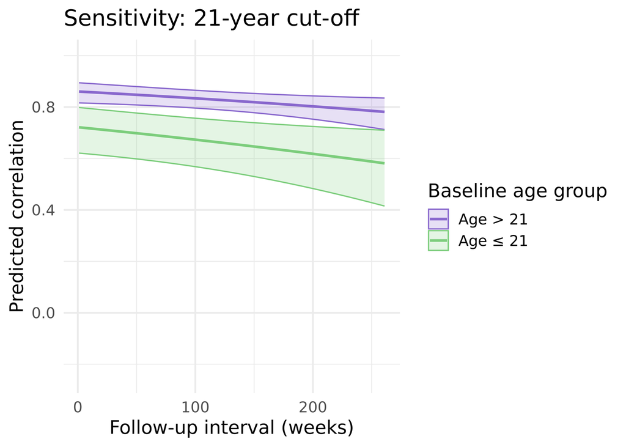

```r
# baseline age - binary variable
data$baseline_age_21 <- cut(data$baseline_age,
                             breaks = c(0, 21, 70),
                             labels = c("0-21", "21+"),  # Labels
                      right = FALSE)

table(data$baseline_age_21)



mod_age_21 <- rma.mv(yi, vi,
                               random=list(~ 1 | es_id, ~ 1 | ref),
                               mods=~baseline_age_21,
                               data=data)
# extract meta-analytic effect sizes for binary age categories
mod_age_21_spec <- rma.mv(yi, vi,
                                    random=list(~ 1 | es_id, ~ 1 | ref),
                                    mods=~baseline_age_21-1,
                                    data=data)


transf.ztor(mod_age_21_spec$beta)
transf.ztor(mod_age_21_spec$ci.lb)
transf.ztor(mod_age_21_spec$ci.ub)



tau2_mod_age21 <- sum(mod_age_21$sigma2)

R2 <- (tau2_res - tau2_mod_age21) / tau2_res

age21_R2 <- R2 *100
age21_R2



# extract k studies
k_age_21 <- data %>%
  filter(!is.na(ES) & !is.na(baseline_age_21)) %>%
  dplyr::count(ref, baseline_age_21) %>%
  dplyr::group_by(baseline_age_21) %>% dplyr::count(baseline_age_21)
# extract total sample size
n_age_21 <- data %>%
  dplyr::filter(!is.na(baseline_age_21) & !is.na(ES)) %>%
  group_by(baseline_age_21, cohort) %>%
  dplyr::count(followup_n) %>%
  dplyr::summarise(m = max(followup_n)) %>%  print(n=100)%>%
  dplyr::summarise(n = sum(m))


# multilevel model with age + time interval

mod_age21_time <- rma.mv(yi, vi,
                               random=list(~ 1 | es_id, ~ 1 | ref),
                               mods=~baseline_age_21 + followup_interval,
                               data=data)

summary(mod_age21_time)

# Plot  model

# Create new data grid for prediction
new_data_1 <- expand.grid(
  baseline_age_21 = c(0, 1),           # 0 = Age ≤ 21, 1 = Age > 21
  followup_interval = 1:261                # Follow-up interval in weeks (up to 5 years)
)

# Generate predictor matrix (drop intercept)
X <- model.matrix(
  ~ baseline_age_21 + followup_interval,
  data = new_data_1
)[, -1]

# Predict from model NOTE: still on z-scale
preds <- predict(mod_age21_time, newmods = X)

# Add predicted values. ALso transform to correlation scale before plotting
new_data_1 <- new_data_1 %>%
  mutate(
    correlation = transf.ztor(preds$pred),
    ci_lower = transf.ztor(preds$ci.lb),
    ci_upper = transf.ztor(preds$ci.ub),
    age_group = ifelse(baseline_age_21 == 0, "Age ≤ 21", "Age > 21")
  )


p_age21_time <- ggplot(new_data_1, aes(x = followup_interval, y = correlation, color = age_group, fill = age_group)) +
  geom_ribbon(aes(ymin = ci_lower, ymax = ci_upper), alpha = 0.2) +
  geom_line(size = 1) +
  scale_y_continuous(limits = c(-0.25, 1)) +
  scale_color_manual(values = c("Age > 21" = "mediumpurple3", "Age ≤ 21" = "palegreen3")) +
  scale_fill_manual(values = c("Age > 21" = "mediumpurple3", "Age ≤ 21" = "palegreen3")) +
  labs(
    title = "Sensitivity: 21-year cut-off",
    x = "Follow-up interval (weeks)",
    y = "Predicted correlation",
    color = "Baseline age group",
    fill = "Baseline age group"
  ) +
  theme_minimal(base_size = 15)

p_age21_time
```

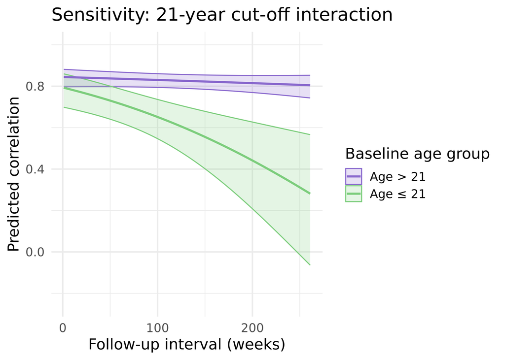

```r
ggsave(
  filename = file.path(Figures, "16_sensitivity_21_cutoff_age_time.pdf"),
  plot = p_age21_time,
  width = 9,
  height = 6
)

#interaction model


# test interaction by baseline age & time interval
mod_age21_interval <- rma.mv(yi, vi,
                               random=list(~ 1 | es_id, ~ 1 | ref),
                               mods=~baseline_age_21 + followup_interval + baseline_age_21*followup_interval,
                               data=data)

summary(mod_age21_interval)



tau2_mod_age21_interval <- sum(mod_age21_interval$sigma2)

R2 <- (tau2_res - tau2_mod_age21_interval) / tau2_res

age21_interval_R2 <- R2 *100
age21_interval_R2



# Plot interaction model

# Create new data grid for prediction
new_data <- expand.grid(
  baseline_age_21 = c(0, 1),           # 0 = Age ≤ 21, 1 = Age > 21
  followup_interval = 1:261                # Follow-up interval in weeks (up to 5 years)
)

# Generate predictor matrix (drop intercept)
X <- model.matrix(
  ~ baseline_age_21 + followup_interval + baseline_age_21 * followup_interval,
  data = new_data
)[, -1]

# Predict from interaction model NOTE: still on z-scale
preds <- predict(mod_age21_interval, newmods = X)

# Add predicted values. ALso transform to correlation scale before plotting
new_data <- new_data %>%
  mutate(
    correlation = transf.ztor(preds$pred),
    ci_lower = transf.ztor(preds$ci.lb),
    ci_upper = transf.ztor(preds$ci.ub),
    age_group = ifelse(baseline_age_21 == 0, "Age ≤ 21", "Age > 21")
  )

p_age21_interval <- ggplot(new_data, aes(x = followup_interval, y = correlation, color = age_group, fill = age_group)) +
  geom_ribbon(aes(ymin = ci_lower, ymax = ci_upper), alpha = 0.2) +
  geom_line(size = 1) +
  scale_y_continuous(limits = c(-0.25, 1)) +
  scale_color_manual(values = c("Age > 21" = "mediumpurple3", "Age ≤ 21" = "palegreen3")) +
  scale_fill_manual(values = c("Age > 21" = "mediumpurple3", "Age ≤ 21" = "palegreen3")) +
  labs(
    title = "Sensitivity: 21-year cut-off interaction",
    x = "Follow-up interval (weeks)",
    y = "Predicted correlation",
    color = "Baseline age group",
    fill = "Baseline age group"
  ) +
  theme_minimal(base_size = 15)

p_age21_interval
```

```r
ggsave(
  filename = file.path(Figures, "17_sensitivity_21_cutoff_interaction.pdf"),
  plot = p_age21_interval,
  width = 9,
  height = 6
)
```

# sensitivity analysis with 24-year cut-off (rather than 18 years)

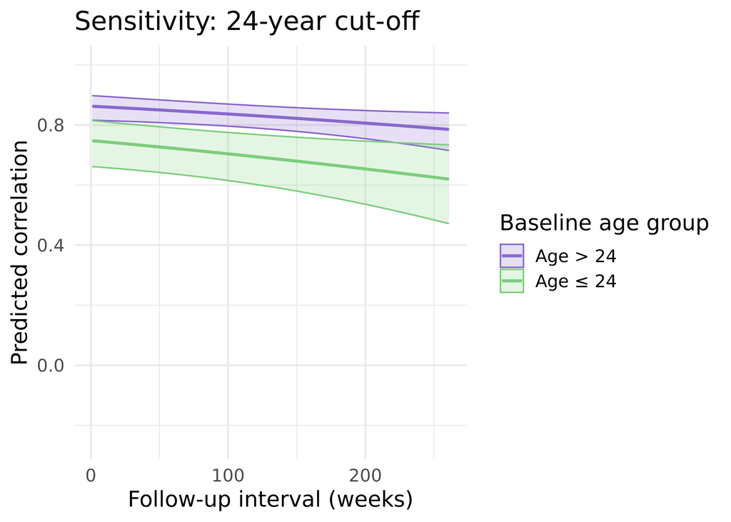

```r
# baseline age - binary variable
data$baseline_age_24 <- cut(data$baseline_age,
                             breaks = c(0, 24, 70),
                             labels = c("0-24", "24+"),  # Labels
                      right = FALSE)

table(data$baseline_age_24)



mod_age_24 <- rma.mv(yi, vi,
                               random=list(~ 1 | es_id, ~ 1 | ref),
                               mods=~baseline_age_24,
                               data=data)
# extract meta-analytic effect sizes for binary age categories
mod_age_24_spec <- rma.mv(yi, vi,
                                    random=list(~ 1 | es_id, ~ 1 | ref),
                                    mods=~baseline_age_24-1,
                                    data=data)

transf.ztor(mod_age_24_spec$beta)
transf.ztor(mod_age_24_spec$ci.lb)
transf.ztor(mod_age_24_spec$ci.ub)


tau2_mod_age24 <- sum(mod_age_24$sigma2)

R2 <- (tau2_res - tau2_mod_age24) / tau2_res

age24_R2 <- R2 *100
age24_R2


# extract k studies
k_age_24 <- data %>%
  filter(!is.na(ES) & !is.na(baseline_age_24)) %>%
  dplyr::count(ref, baseline_age_24) %>%
  dplyr::group_by(baseline_age_24) %>% dplyr::count(baseline_age_24)
# extract total sample size
n_age_24 <- data %>%
  dplyr::filter(!is.na(baseline_age_24) & !is.na(ES)) %>%
  group_by(baseline_age_24, cohort) %>%
  dplyr::count(followup_n) %>%
  dplyr::summarise(m = max(followup_n)) %>%  print(n=100)%>%
  dplyr::summarise(n = sum(m))




# multilevel model with age + time interval

mod_age24_time <- rma.mv(yi, vi,
                               random=list(~ 1 | es_id, ~ 1 | ref),
                               mods=~baseline_age_24 + followup_interval,
                               data=data)

summary(mod_age24_time)

# Plot  model

# Create new data grid for prediction
new_data_1 <- expand.grid(
  baseline_age_24 = c(0, 1),           # 0 = Age ≤ 24, 1 = Age > 24
  followup_interval = 1:261                # Follow-up interval in weeks (up to 5 years)
)

# Generate predictor matrix (drop intercept)
X <- model.matrix(
  ~ baseline_age_24 + followup_interval,
  data = new_data_1
)[, -1]

# Predict from model NOTE: still on z-scale
preds <- predict(mod_age24_time, newmods = X)

# Add predicted values. ALso transform to correlation scale before plotting
new_data_1 <- new_data_1 %>%
  mutate(
    correlation = transf.ztor(preds$pred),
    ci_lower = transf.ztor(preds$ci.lb),
    ci_upper = transf.ztor(preds$ci.ub),
    age_group = ifelse(baseline_age_24 == 0, "Age ≤ 24", "Age > 24")
  )

p_age24_time <- ggplot(new_data_1, aes(x = followup_interval, y = correlation, color = age_group, fill = age_group)) +
  geom_ribbon(aes(ymin = ci_lower, ymax = ci_upper), alpha = 0.2) +
  geom_line(size = 1) +
  scale_y_continuous(limits = c(-0.25, 1)) +
  scale_color_manual(values = c("Age > 24" = "mediumpurple3", "Age ≤ 24" = "palegreen3")) +
  scale_fill_manual(values = c("Age > 24" = "mediumpurple3", "Age ≤ 24" = "palegreen3")) +
  labs(
    title = "Sensitivity: 24-year cut-off",
    x = "Follow-up interval (weeks)",
    y = "Predicted correlation",
    color = "Baseline age group",
    fill = "Baseline age group"
  ) +
  theme_minimal(base_size = 15)

p_age24_time
```

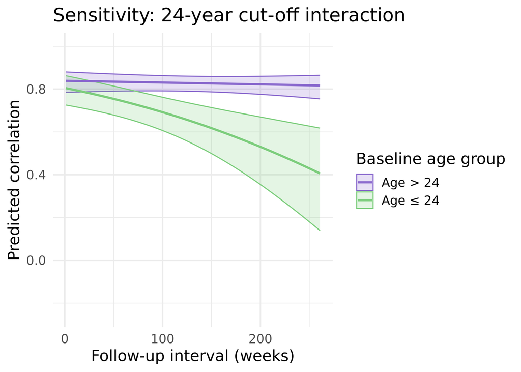

```r
ggsave(
  filename = file.path(Figures, "18_sensitivity_24_cutoff_age_time.pdf"),
  plot = p_age24_time,
  width = 9,
  height = 6
)

#interaction model


# test interaction by baseline age & time interval
mod_age24_interval <- rma.mv(yi, vi,
                               random=list(~ 1 | es_id, ~ 1 | ref),
                               mods=~baseline_age_24 + followup_interval + baseline_age_24*followup_interval,
                               data=data)

summary(mod_age24_interval)



tau2_mod_age24_interval <- sum(mod_age24_interval$sigma2)

R2 <- (tau2_res - tau2_mod_age24_interval) / tau2_res

age24_interval_R2 <- R2 *100
age24_interval_R2


# Plot interaction model

# Create new data grid for prediction
new_data <- expand.grid(
  baseline_age_24 = c(0, 1),           # 0 = Age ≤ 24, 1 = Age > 24
  followup_interval = 1:261                # Follow-up interval in weeks (up to 5 years)
)

# Generate predictor matrix (drop intercept)
X <- model.matrix(
  ~ baseline_age_24 + followup_interval + baseline_age_24 * followup_interval,
  data = new_data
)[, -1]

# Predict from interaction model NOTE: still on z-scale
preds <- predict(mod_age24_interval, newmods = X)

# Add predicted values. ALso transform to correlation scale before plotting
new_data <- new_data %>%
  mutate(
    correlation = transf.ztor(preds$pred),
    ci_lower = transf.ztor(preds$ci.lb),
    ci_upper = transf.ztor(preds$ci.ub),
    age_group = ifelse(baseline_age_24 == 0, "Age ≤ 24", "Age > 24")
  )

p_age24_interval <- ggplot(new_data, aes(x = followup_interval, y = correlation, color = age_group, fill = age_group)) +
  geom_ribbon(aes(ymin = ci_lower, ymax = ci_upper), alpha = 0.2) +
  geom_line(size = 1) +
  scale_y_continuous(limits = c(-0.25, 1)) +
  scale_color_manual(values = c("Age > 24" = "mediumpurple3", "Age ≤ 24" = "palegreen3")) +
  scale_fill_manual(values = c("Age > 24" = "mediumpurple3", "Age ≤ 24" = "palegreen3")) +
  labs(
    title = "Sensitivity: 24-year cut-off interaction",
    x = "Follow-up interval (weeks)",
    y = "Predicted correlation",
    color = "Baseline age group",
    fill = "Baseline age group"
  ) +
  theme_minimal(base_size = 15)

p_age24_interval
```

```r
ggsave(
  filename = file.path(Figures, "19_sensitivity_24_cutoff_interaction.pdf"),
  plot = p_age24_interval,
  width = 9,
  height = 6
)
```

## sensitivity check for exploratory age analyses above - excluding breton and park

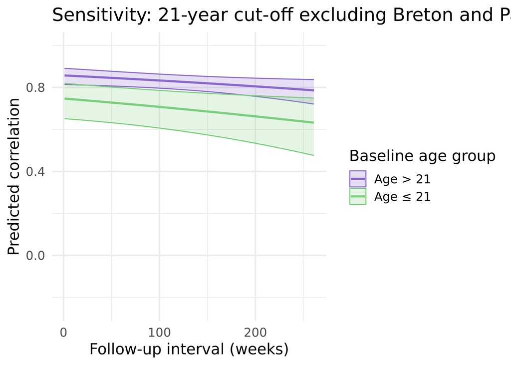

```r
# baseline age - binary variable
data_excl$baseline_age_21 <- cut(data_excl$baseline_age,
                             breaks = c(0, 21, 70),
                             labels = c("0-21", "21+"),  # Labels
                      right = FALSE)

table(data_excl$baseline_age_21)



mod_age_21 <- rma.mv(yi, vi,
                               random=list(~ 1 | es_id, ~ 1 | ref),
                               mods=~baseline_age_21,
                               data=data_excl)
# extract meta-analytic effect sizes for binary age categories
mod_age_21_spec <- rma.mv(yi, vi,
                                    random=list(~ 1 | es_id, ~ 1 | ref),
                                    mods=~baseline_age_21-1,
                                    data=data_excl)


transf.ztor(mod_age_21_spec$beta)
transf.ztor(mod_age_21_spec$ci.lb)
transf.ztor(mod_age_21_spec$ci.ub)



tau2_mod_age_21 <- sum(mod_age_21$sigma2)

R2 <- (tau2_res - tau2_mod_age) / tau2_res

age21_R2 <- R2 *100
age21_R2




# extract k studies
k_age_21 <- data_excl %>%
  filter(!is.na(ES) & !is.na(baseline_age_21)) %>%
  dplyr::count(ref, baseline_age_21) %>%
  dplyr::group_by(baseline_age_21) %>% dplyr::count(baseline_age_21)
# extract total sample size
n_age_21 <- data_excl %>%
  dplyr::filter(!is.na(baseline_age_21) & !is.na(ES)) %>%
  group_by(baseline_age_21, cohort) %>%
  dplyr::count(followup_n) %>%
  dplyr::summarise(m = max(followup_n)) %>%  print(n=100)%>%
  dplyr::summarise(n = sum(m))


# multilevel model with age + time interval

mod_age21_time <- rma.mv(yi, vi,
                               random=list(~ 1 | es_id, ~ 1 | ref),
                               mods=~baseline_age_21 + followup_interval,
                               data=data_excl)

summary(mod_age21_time)

# Plot  model

# Create new data grid for prediction
new_data_1 <- expand.grid(
  baseline_age_21 = c(0, 1),           # 0 = Age ≤ 21, 1 = Age > 21
  followup_interval = 1:261                # Follow-up interval in weeks (up to 5 years)
)

# Generate predictor matrix (drop intercept)
X <- model.matrix(
  ~ baseline_age_21 + followup_interval,
  data = new_data_1
)[, -1]

# Predict from model NOTE: still on z-scale
preds <- predict(mod_age21_time, newmods = X)

# Add predicted values. ALso transform to correlation scale before plotting
new_data_1 <- new_data_1 %>%
  mutate(
    correlation = transf.ztor(preds$pred),
    ci_lower = transf.ztor(preds$ci.lb),
    ci_upper = transf.ztor(preds$ci.ub),
    age_group = ifelse(baseline_age_21 == 0, "Age ≤ 21", "Age > 21")
  )

p_age21_time_excl <- ggplot(new_data_1, aes(x = followup_interval, y = correlation, color = age_group, fill = age_group)) +
  geom_ribbon(aes(ymin = ci_lower, ymax = ci_upper), alpha = 0.2) +
  geom_line(size = 1) +
  scale_y_continuous(limits = c(-0.25, 1)) +
  scale_color_manual(values = c("Age > 21" = "mediumpurple3", "Age ≤ 21" = "palegreen3")) +
  scale_fill_manual(values = c("Age > 21" = "mediumpurple3", "Age ≤ 21" = "palegreen3")) +
  labs(
    title = "Sensitivity: 21-year cut-off excluding Breton and Park",
    x = "Follow-up interval (weeks)",
    y = "Predicted correlation",
    color = "Baseline age group",
    fill = "Baseline age group"
  ) +
  theme_minimal(base_size = 15)

p_age21_time_excl
```

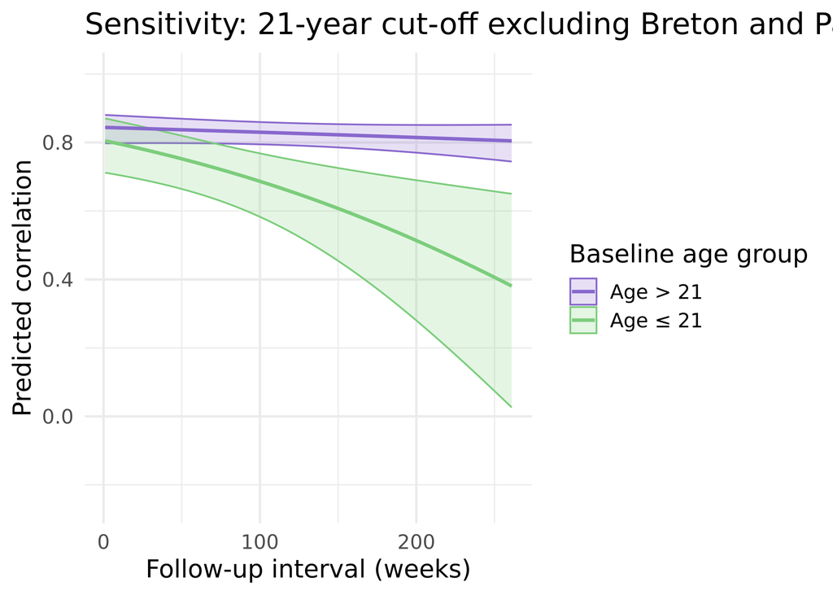

```r
ggsave(
  filename = file.path(Figures, "20_sensitivity_21_cutoff_breton_park_age_time.pdf"),
  plot = p_age21_time_excl,
  width = 9,
  height = 6
)

#interaction model


# test interaction by baseline age & time interval
mod_age21_interval <- rma.mv(yi, vi,
                               random=list(~ 1 | es_id, ~ 1 | ref),
                               mods=~baseline_age_21 + followup_interval + baseline_age_21*followup_interval,
                               data=data_excl)

summary(mod_age21_interval)


tau2_mod_age21_interval <- sum(mod_age21_interval$sigma2)

R2 <- (tau2_res - tau2_mod_age21_interval) / tau2_res

age21_interval_R2 <- R2 *100
age21_interval_R2


# Plot interaction model

# Create new data grid for prediction
new_data <- expand.grid(
  baseline_age_21 = c(0, 1),           # 0 = Age ≤ 21, 1 = Age > 21
  followup_interval = 1:261                # Follow-up interval in weeks (up to 5 years)
)

# Generate predictor matrix (drop intercept)
X <- model.matrix(
  ~ baseline_age_21 + followup_interval + baseline_age_21 * followup_interval,
  data = new_data
)[, -1]

# Predict from interaction model NOTE: still on z-scale
preds <- predict(mod_age21_interval, newmods = X)

# Add predicted values. ALso transform to correlation scale before plotting
new_data <- new_data %>%
  mutate(
    correlation = transf.ztor(preds$pred),
    ci_lower = transf.ztor(preds$ci.lb),
    ci_upper = transf.ztor(preds$ci.ub),
    age_group = ifelse(baseline_age_21 == 0, "Age ≤ 21", "Age > 21")
  )

p_age21_interval_excl <- ggplot(new_data, aes(x = followup_interval, y = correlation, color = age_group, fill = age_group)) +
  geom_ribbon(aes(ymin = ci_lower, ymax = ci_upper), alpha = 0.2) +
  geom_line(size = 1) +
  scale_y_continuous(limits = c(-0.25, 1)) +
  scale_color_manual(values = c("Age > 21" = "mediumpurple3", "Age ≤ 21" = "palegreen3")) +
  scale_fill_manual(values = c("Age > 21" = "mediumpurple3", "Age ≤ 21" = "palegreen3")) +
  labs(
    title = "Sensitivity: 21-year cut-off excluding Breton and Park interaction",
    x = "Follow-up interval (weeks)",
    y = "Predicted correlation",
    color = "Baseline age group",
    fill = "Baseline age group"
  ) +
  theme_minimal(base_size = 15)

p_age21_interval_excl
```

```r
ggsave(
  filename = file.path(Figures, "21_sensitivity_21_cutoff_breton_park_interaction.pdf"),
  plot = p_age21_interval_excl,
  width = 9,
  height = 6
)


tau2_mod_age21_interval <- sum(mod_age21_interval$sigma2)

R2 <- (tau2_res - tau2_mod_age21_interval) / tau2_res

age21_interval_R2 <- R2 *100
age21_interval_R2
```

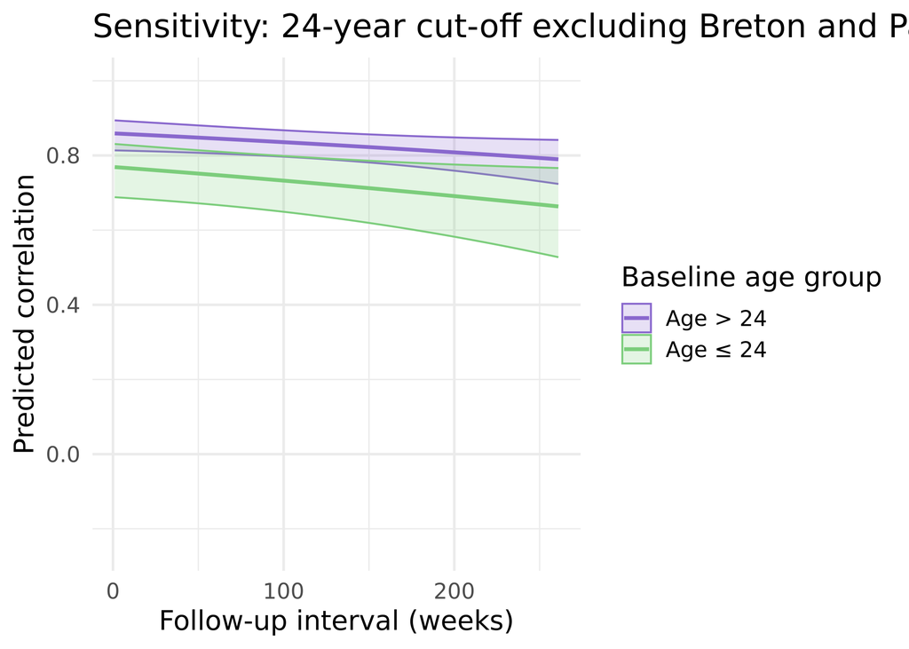

```r
# baseline age - binary variable
data_excl$baseline_age_24 <- cut(data_excl$baseline_age,
                             breaks = c(0, 24, 70),
                             labels = c("0-24", "24+"),  # Labels
                      right = FALSE)

table(data_excl$baseline_age_24)



mod_age_24 <- rma.mv(yi, vi,
                               random=list(~ 1 | es_id, ~ 1 | ref),
                               mods=~baseline_age_24,
                               data=data_excl)
# extract meta-analytic effect sizes for binary age categories
mod_age_24_spec <- rma.mv(yi, vi,
                                    random=list(~ 1 | es_id, ~ 1 | ref),
                                    mods=~baseline_age_24-1,
                                    data=data_excl)

transf.ztor(mod_age_24_spec$beta)
transf.ztor(mod_age_24_spec$ci.lb)
transf.ztor(mod_age_24_spec$ci.ub)



tau2_mod_age_24 <- sum(mod_age_24$sigma2)

R2 <- (tau2_res - tau2_mod_age_24) / tau2_res

age_24_R2 <- R2 *100
age_24_R2




# extract k studies
k_age_24 <- data_excl %>%
  filter(!is.na(ES) & !is.na(baseline_age_24)) %>%
  dplyr::count(ref, baseline_age_24) %>%
  dplyr::group_by(baseline_age_24) %>% dplyr::count(baseline_age_24)
# extract total sample size
n_age_24 <- data_excl %>%
  dplyr::filter(!is.na(baseline_age_24) & !is.na(ES)) %>%
  group_by(baseline_age_24, cohort) %>%
  dplyr::count(followup_n) %>%
  dplyr::summarise(m = max(followup_n)) %>%  print(n=100)%>%
  dplyr::summarise(n = sum(m))




# multilevel model with age + time interval

mod_age24_time <- rma.mv(yi, vi,
                               random=list(~ 1 | es_id, ~ 1 | ref),
                               mods=~baseline_age_24 + followup_interval,
                               data=data_excl)

summary(mod_age24_time)

# Plot  model

# Create new data grid for prediction
new_data_1 <- expand.grid(
  baseline_age_24 = c(0, 1),           # 0 = Age ≤ 24, 1 = Age > 24
  followup_interval = 1:261                # Follow-up interval in weeks (up to 5 years)
)

# Generate predictor matrix (drop intercept)
X <- model.matrix(
  ~ baseline_age_24 + followup_interval,
  data = new_data_1
)[, -1]

# Predict from model NOTE: still on z-scale
preds <- predict(mod_age24_time, newmods = X)

# Add predicted values. ALso transform to correlation scale before plotting
new_data_1 <- new_data_1 %>%
  mutate(
    correlation = transf.ztor(preds$pred),
    ci_lower = transf.ztor(preds$ci.lb),
    ci_upper = transf.ztor(preds$ci.ub),
    age_group = ifelse(baseline_age_24 == 0, "Age ≤ 24", "Age > 24")
  )

p_age24_time_excl <- ggplot(new_data_1, aes(x = followup_interval, y = correlation, color = age_group, fill = age_group)) +
  geom_ribbon(aes(ymin = ci_lower, ymax = ci_upper), alpha = 0.2) +
  geom_line(size = 1) +
  scale_y_continuous(limits = c(-0.25, 1)) +
  scale_color_manual(values = c("Age > 24" = "mediumpurple3", "Age ≤ 24" = "palegreen3")) +
  scale_fill_manual(values = c("Age > 24" = "mediumpurple3", "Age ≤ 24" = "palegreen3")) +
  labs(
    title = "Sensitivity: 24-year cut-off excluding Breton and Park",
    x = "Follow-up interval (weeks)",
    y = "Predicted correlation",
    color = "Baseline age group",
    fill = "Baseline age group"
  ) +
  theme_minimal(base_size = 15)

p_age24_time_excl
```

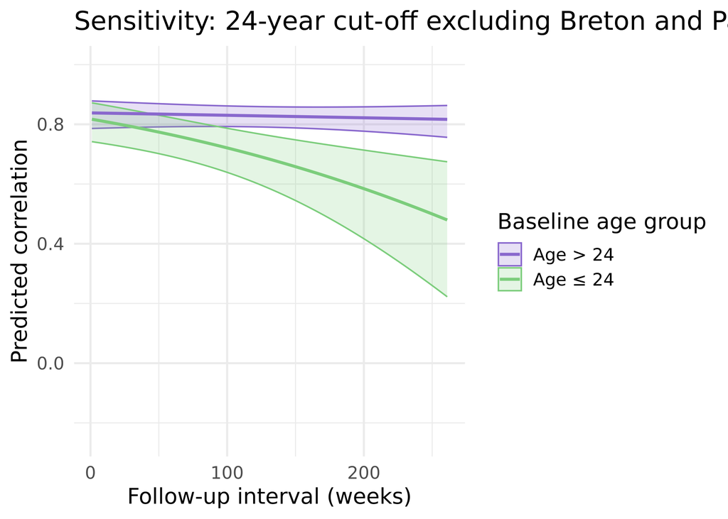

```r
ggsave(
  filename = file.path(Figures, "22_sensitivity_24_cutoff_breton_park_age_time.pdf"),
  plot = p_age24_time_excl,
  width = 9,
  height = 6
)

#interaction model


# test interaction by baseline age & time interval
mod_age24_interval <- rma.mv(yi, vi,
                               random=list(~ 1 | es_id, ~ 1 | ref),
                               mods=~baseline_age_24 + followup_interval + baseline_age_24*followup_interval,
                               data=data_excl)

summary(mod_age24_interval)




tau2_mod_age24_interval <- sum(mod_age24_interval$sigma2)

R2 <- (tau2_res - tau2_mod_age24_interval) / tau2_res

age24_interval_R2 <- R2 *100
age24_interval_R2



# Plot interaction model

# Create new data grid for prediction
new_data <- expand.grid(
  baseline_age_24 = c(0, 1),           # 0 = Age ≤ 24, 1 = Age > 24
  followup_interval = 1:261                # Follow-up interval in weeks (up to 5 years)
)

# Generate predictor matrix (drop intercept)
X <- model.matrix(
  ~ baseline_age_24 + followup_interval + baseline_age_24 * followup_interval,
  data = new_data
)[, -1]

# Predict from interaction model NOTE: still on z-scale
preds <- predict(mod_age24_interval, newmods = X)

# Add predicted values. ALso transform to correlation scale before plotting
new_data <- new_data %>%
  mutate(
    correlation = transf.ztor(preds$pred),
    ci_lower = transf.ztor(preds$ci.lb),
    ci_upper = transf.ztor(preds$ci.ub),
    age_group = ifelse(baseline_age_24 == 0, "Age ≤ 24", "Age > 24")
  )

p_age24_interval_excl <- ggplot(new_data, aes(x = followup_interval, y = correlation, color = age_group, fill = age_group)) +
  geom_ribbon(aes(ymin = ci_lower, ymax = ci_upper), alpha = 0.2) +
  geom_line(size = 1) +
  scale_y_continuous(limits = c(-0.25, 1)) +
  scale_color_manual(values = c("Age > 24" = "mediumpurple3", "Age ≤ 24" = "palegreen3")) +
  scale_fill_manual(values = c("Age > 24" = "mediumpurple3", "Age ≤ 24" = "palegreen3")) +
  labs(
    title = "Sensitivity: 24-year cut-off excluding Breton and Park interaction",
    x = "Follow-up interval (weeks)",
    y = "Predicted correlation",
    color = "Baseline age group",
    fill = "Baseline age group"
  ) +
  theme_minimal(base_size = 15)

p_age24_interval_excl
```

```r
ggsave(
  filename = file.path(Figures, "23_sensitivity_24_cutoff_breton_park_interaction.pdf"),
  plot = p_age24_interval_excl,
  width = 9,
  height = 6
)
```